# CDC Daily by State

davegoblue

4/14/2021

## Background

This file is designed to use CDC data to assess coronavirus disease burden by state, including creating and analyzing state-level cluters.

Through March 7, 2021, [The COVID Tracking Project](https://covidtracking.com/) collected and integrated data on tests, cases, hospitalizations, deaths, and the like by state and date. The latest code for using this data is available in Coronavirus_Statistics_CTP_v004.Rmd.

The COVID Tracking Project suggest that [US federal data sources](https://covidtracking.com/analysis-updates/federal-covid-data-101-how-to-find-data) are now sufficiently robust to be used for analyses that previously relied on COVID Tracking Project. This code is an attempt to update modules in Coronavirus_Statistics_CTP_v004.Rmd to leverage US federal data.

The code leverages tidyverse and a variable mapping file throughout:

```r
# All functions assume that tidyverse and its components are loaded and available
# Other functions are declared in the sourcing files or use library::function()
library(tidyverse)
```

```r
# For future use, source key modules from a separate .R file

# Create a variable mapping file - this is not yest updated for federal data
varMapper <- c("cases"="Cases",
               "tot_cases"="Total cases",
               "newCases"="Increase in cases, most recent 30 days",
               "casesroll7"="Rolling 7-day mean cases",
               "deaths"="Deaths",
               "tot_deaths"="Total deaths",
               "newDeaths"="Increase in deaths, most recent 30 days",
               "deathsroll7"="Rolling 7-day mean deaths",
               "cpm"="Cases per million",
               "cpm7"="Cases per day (7-day rolling mean) per million",
               "tcpm"="Total cases per million",
               "newcpm"="Increase in cases, most recent 30 days, per million",
               "dpm"="Deaths per million",
               "dpm7"="Deaths per day (7-day rolling mean) per million",
               "tdpm"="Total deaths per million",
               "newdpm"="Increase in deaths, most recent 30 days, per million",
               "hpm7"="Currently Hospitalized per million (7-day rolling mean)",
               "tpm"="Tests per million",
               "tpm7"="Tests per million per day (7-day rolling mean)"
               )

# Helper functions used early in the process
# Function for saving an R object to RDS, including a check for whether the object already exists
saveToRDS <- function(obj,
                      file=paste0(deparse(substitute(obj)), ".RDS"),
                      dir="./RInputFiles/Coronavirus/",
                      ovrWrite=FALSE,
                      ovrWriteError=TRUE,
                      makeReadOnly=TRUE
                      ) {

    # FUNCTION ARGUMENTS:
    # obj: the R object to save
    # file: the file name to save as
    # dir: the directory to save in (file path will be paste0(dir, file))
    # ovrWrite: boolean, should the file be overwritten if it already exists?
    # ovrWriteError: boolean, should an error be thrown if an attempt is made to overwrite the file?
    # makeReadOnly: boolean, should the output file be made read-only?

    # Create the file name
    locFile <- paste0(dir, file)

    # Check if the file already exists and proceed as per options
    if (file.exists(locFile)) {
        cat("\nFile already exists:", locFile, "\n")
        if (!ovrWrite & ovrWriteError) stop("\nAborting due to ovrWrite=FALSE and ovrWriteError=TRUE")
        if (!ovrWrite) {
            cat("\nNot replacing the existing file since ovrWrite=FALSE\n")
            return(NULL)
        }
    }

    # Save the file and update the permissions to read-only (if flag is set)
    saveRDS(obj, file=locFile)
    if (makeReadOnly) Sys.chmod(locFile, mode="0555", use_umask = FALSE)

}



# Function for reading an R object from RDS
readFromRDS <- function(file,
                        dir="./RInputFiles/Coronavirus/",
                        addSuffix=".RDS",
                        deparseSub=FALSE
                        ) {

    # FUNCTION ARGUMENTS:
    # file: the file name to read in
    # dir: the directory the file is in
    # addSuffix: the suffix that should be added to file (file path will be paste0(dir, file, addSuffix))
    # deparseSub: whether to deparse and substitute file (use it as the text name)

    # Convert file if needed
    if (deparseSub) file <- deparse(substitute(file))

    # Ensure that file is of type character
    if (!isTRUE(all.equal(class(file), "character"))) {
        stop("\nUnable to read since file is not a character\n")
    }

    # Create the file name
    locFile <- paste0(dir, file, addSuffix)

    # Read the file (will be the return)
    readRDS(locFile)

}
```

### Downloading and Integrating US Federal Data

#### *Cases and Deaths by State-Date*

CDC case and death data by state and date are available for download on the [CDC website](https://data.cdc.gov/api/views/9mfq-cb36/rows.csv?accessType=DOWNLOAD). The previously written function downloadCOVIDbyState() can be used to acquire the data by updating the API:

```r
# NO CHANGES MADE TO FUNCTION - default API is from COVID Tracking Project
# Function to download data for COVID Tracking Project
downloadCOVIDbyState <- function(fileName,
                                 api="https://api.covidtracking.com/v1/states/daily.csv",
                                 ovrWrite=FALSE
                                 ) {

    # FUNCTION ARGUMENTS:
    # fileName: the filename that the data will be saved to
    # api: The API link for data downloads
    # ovrWrite: whether to allow overwriting of the existing fileName

    # Check whether fileName already exists
    if (file.exists(fileName)) {
        cat("\nFile already exists at:", fileName, "\n")
        if (ovrWrite) cat("Will over-write with current data from", api, "\n")
        else stop("Exiting due to ovrWrite=FALSE and a duplicate fileName\n")
    }

    # Download the file
    download.file(api, destfile=fileName)

    # Show statistics on downloaded file
    file.info(fileName)

}
```

The data are downloaded and the process cached to avoid repeated hits against the CDC website:

```r
downloadCOVIDbyState("./RInputFiles/Coronavirus/CDC_dc_downloaded_210414.csv",
                     api="https://data.cdc.gov/api/views/9mfq-cb36/rows.csv?accessType=DOWNLOAD",
                     ovrWrite=FALSE
                     )
```

```
##                                                           size isdir mode
## ./RInputFiles/Coronavirus/CDC_dc_downloaded_210414.csv 2180440 FALSE  666
##                                                                      mtime
## ./RInputFiles/Coronavirus/CDC_dc_downloaded_210414.csv 2021-04-14 08:57:22
##                                                                      ctime
## ./RInputFiles/Coronavirus/CDC_dc_downloaded_210414.csv 2021-04-14 08:57:19
##                                                                      atime exe
## ./RInputFiles/Coronavirus/CDC_dc_downloaded_210414.csv 2021-04-14 08:57:22  no
```

Key fields from the documentation include:

- submission_date - date of counts
- state - state (includes 50 states, DC, NYC, and 8 territories/federations)
- tot_cases - cumulative number of cases (confirmed and probable)
- new_case - new cases (confirmed and probable)
- tot_death - cumulative number of deaths (confirmed and probable)
- new_death - new deaths (confirmed and probable)
- consent_cases - boolean tracked as “Agree” (confirmed and probable tracked separately) or “Not Agree” (only total tracked)
- consent_deaths - boolean tracked as “Agree” or “Not Agree” (same as for consent_cases)

Basic formatting and QC is run on the downloaded data (this can later be converted to functional form):

```r
# Read and glimpse downloaded CDC file
cdcRaw <- readr::read_csv("./RInputFiles/Coronavirus/CDC_dc_downloaded_210414.csv")
glimpse(cdcRaw)
```

```
## Rows: 26,820
## Columns: 15
## $ submission_date <chr> "01/01/2021", "04/30/2020", "02/26/2020", "03/05/20...
## $ state           <chr> "FL", "IA", "UT", "GA", "WV", "NY", "GA", "TN", "AS...
## $ tot_cases       <dbl> 1300528, 7145, 0, 2, 1224, 346492, 28196, 143937, 0...
## $ conf_cases      <dbl> NA, NA, NA, NA, 1224, NA, 28182, 141000, NA, NA, NA...
## $ prob_cases      <dbl> NA, NA, NA, NA, 0, NA, 14, 2937, NA, NA, NA, NA, 15...
## $ new_case        <dbl> 0, 302, 0, -5, 29, 5775, 602, 1854, 0, 0, 7598, 55,...
## $ pnew_case       <dbl> 6063, 0, NA, NA, 0, 0, 1, 38, 0, 0, 0, 0, 781, 705,...
## $ tot_death       <dbl> 21673, 162, 0, 0, 50, 10117, 1258, 1567, 0, 0, 1117...
## $ conf_death      <dbl> NA, NA, NA, NA, NA, NA, 1258, 1527, NA, NA, NA, NA,...
## $ prob_death      <dbl> NA, NA, NA, NA, NA, NA, 0, 40, NA, NA, NA, NA, 5080...
## $ new_death       <dbl> 0, 14, 0, 0, 0, 56, 47, 4, 0, 0, 229, 3, 60, 10, 3,...
## $ pnew_death      <dbl> 7, 0, NA, NA, 0, 0, 0, 0, 0, 0, 0, 0, 6, 2, 1, 478,...
## $ created_at      <chr> "01/02/2021 02:50:51 PM", "05/01/2020 09:00:19 PM",...
## $ consent_cases   <chr> "Not agree", "Not agree", "Agree", "Agree", "Agree"...
## $ consent_deaths  <chr> "Not agree", "Not agree", "Agree", "Agree", "Not ag...
```

```r
# Check for variables in the consent_ fields
cdcRaw %>%
    count(consent_cases, consent_deaths)
```

```
## # A tibble: 10 x 3
##    consent_cases consent_deaths     n
##    <chr>         <chr>          <int>
##  1 Agree         Agree          12487
##  2 Agree         N/A              447
##  3 Agree         Not agree       1788
##  4 N/A           Agree           1341
##  5 N/A           N/A              894
##  6 N/A           Not agree        447
##  7 Not agree     Agree           1370
##  8 Not agree     N/A              447
##  9 Not agree     Not agree       5364
## 10 <NA>          <NA>            2235
```

```r
# Function to convert N/A, Agree, and Not agree to boolean
cdcToBool <- function(x) {
    y <- case_when(is.na(x) ~ "NA",
                   x=="N/A" ~ "NA",
                   x=="Agree" ~ "TRUE",
                   x=="Not agree" ~ "FALSE",
                   TRUE ~ "Problem"
                   )
    if (sum(y=="Problem") != 0) stop("Problem with the boolean conversion")
    y[y=="NA"] <- NA
    as.logical(y)
}

# Format fields as desired types
cdcProcessed <- cdcRaw %>%
    mutate(date=lubridate::mdy(submission_date),
           creation_date=lubridate::mdy_hms(created_at),
           bool_c_cases=cdcToBool(consent_cases),
           bool_c_deaths=cdcToBool(consent_deaths)
           )
glimpse(cdcProcessed)
```

```
## Rows: 26,820
## Columns: 19
## $ submission_date <chr> "01/01/2021", "04/30/2020", "02/26/2020", "03/05/20...
## $ state           <chr> "FL", "IA", "UT", "GA", "WV", "NY", "GA", "TN", "AS...
## $ tot_cases       <dbl> 1300528, 7145, 0, 2, 1224, 346492, 28196, 143937, 0...
## $ conf_cases      <dbl> NA, NA, NA, NA, 1224, NA, 28182, 141000, NA, NA, NA...
## $ prob_cases      <dbl> NA, NA, NA, NA, 0, NA, 14, 2937, NA, NA, NA, NA, 15...
## $ new_case        <dbl> 0, 302, 0, -5, 29, 5775, 602, 1854, 0, 0, 7598, 55,...
## $ pnew_case       <dbl> 6063, 0, NA, NA, 0, 0, 1, 38, 0, 0, 0, 0, 781, 705,...
## $ tot_death       <dbl> 21673, 162, 0, 0, 50, 10117, 1258, 1567, 0, 0, 1117...
## $ conf_death      <dbl> NA, NA, NA, NA, NA, NA, 1258, 1527, NA, NA, NA, NA,...
## $ prob_death      <dbl> NA, NA, NA, NA, NA, NA, 0, 40, NA, NA, NA, NA, 5080...
## $ new_death       <dbl> 0, 14, 0, 0, 0, 56, 47, 4, 0, 0, 229, 3, 60, 10, 3,...
## $ pnew_death      <dbl> 7, 0, NA, NA, 0, 0, 0, 0, 0, 0, 0, 0, 6, 2, 1, 478,...
## $ created_at      <chr> "01/02/2021 02:50:51 PM", "05/01/2020 09:00:19 PM",...
## $ consent_cases   <chr> "Not agree", "Not agree", "Agree", "Agree", "Agree"...
## $ consent_deaths  <chr> "Not agree", "Not agree", "Agree", "Agree", "Not ag...
## $ date            <date> 2021-01-01, 2020-04-30, 2020-02-26, 2020-03-05, 20...
## $ creation_date   <dttm> 2021-01-02 14:50:51, 2020-05-01 21:00:19, 2020-03-...
## $ bool_c_cases    <lgl> FALSE, FALSE, TRUE, TRUE, TRUE, FALSE, TRUE, TRUE, ...
## $ bool_c_deaths   <lgl> FALSE, FALSE, TRUE, TRUE, FALSE, FALSE, TRUE, TRUE,...
```

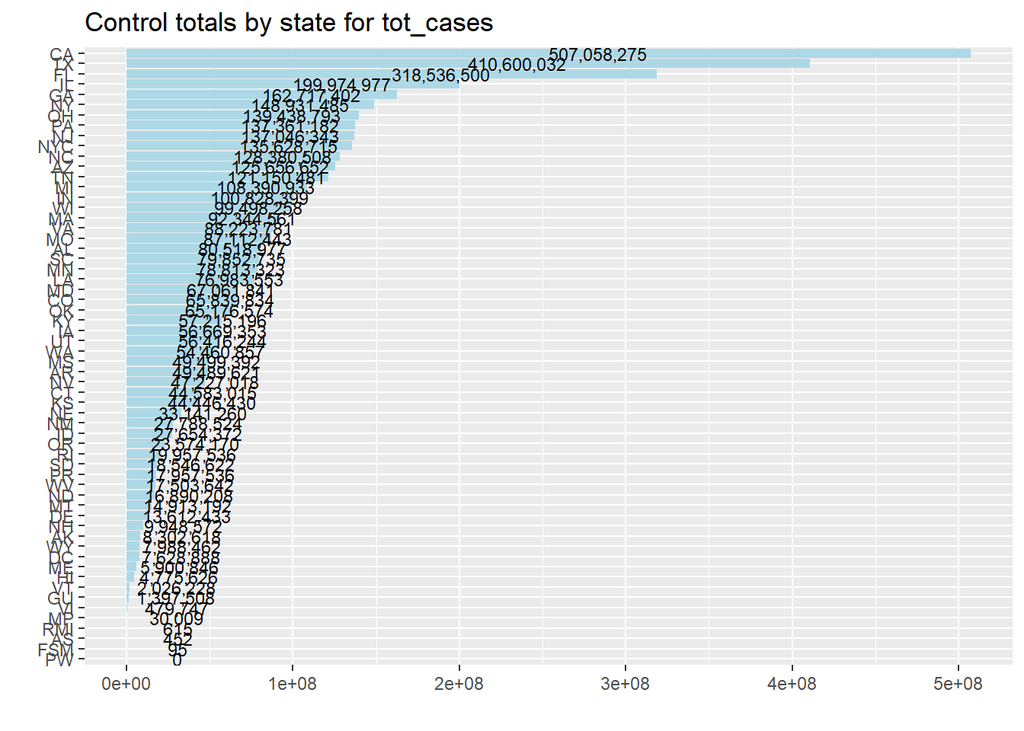

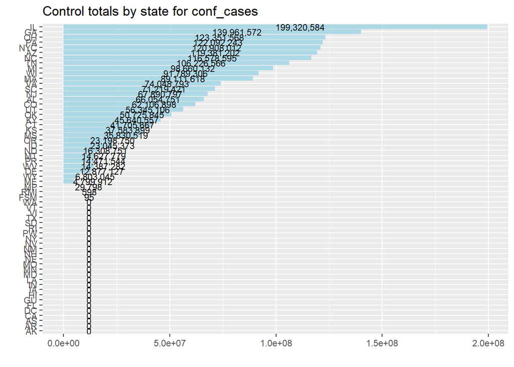

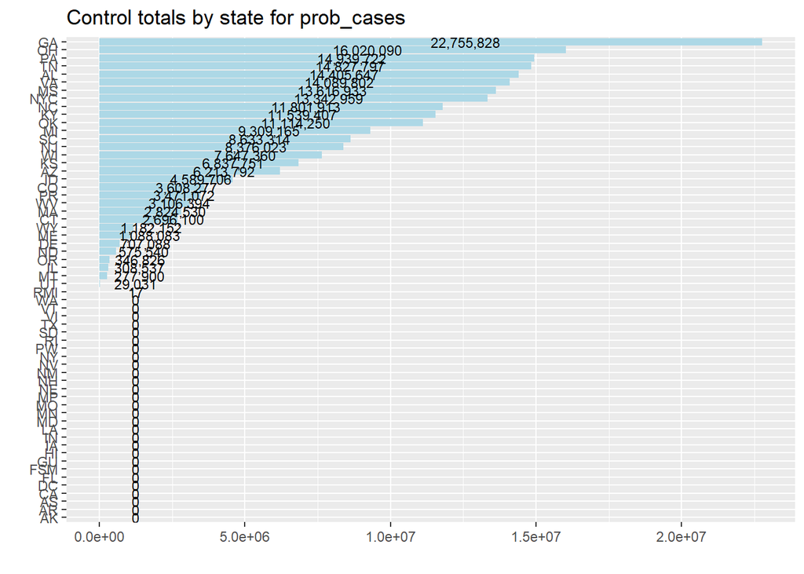

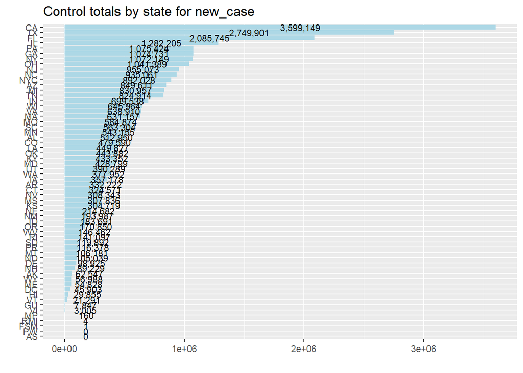

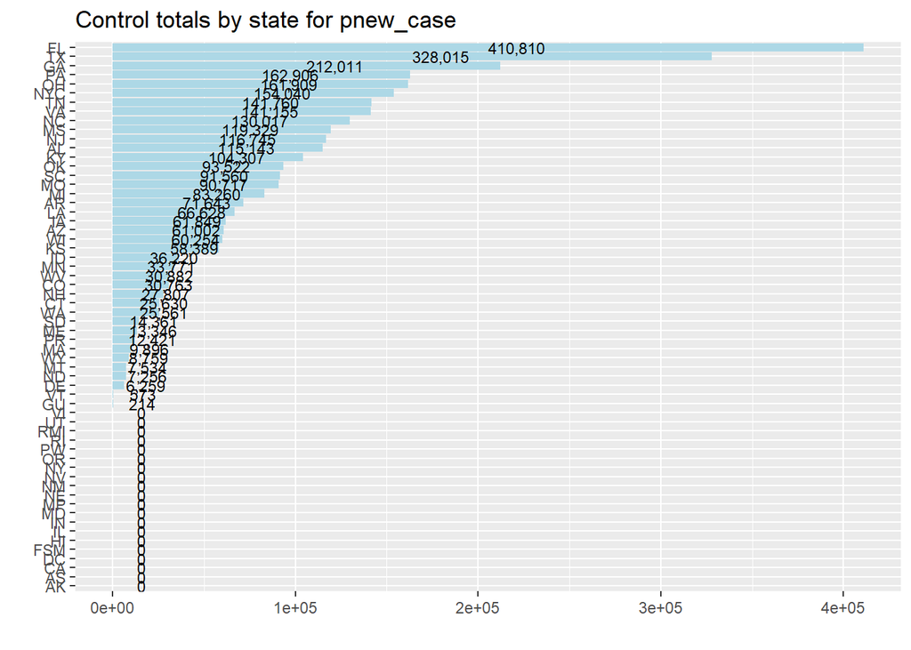

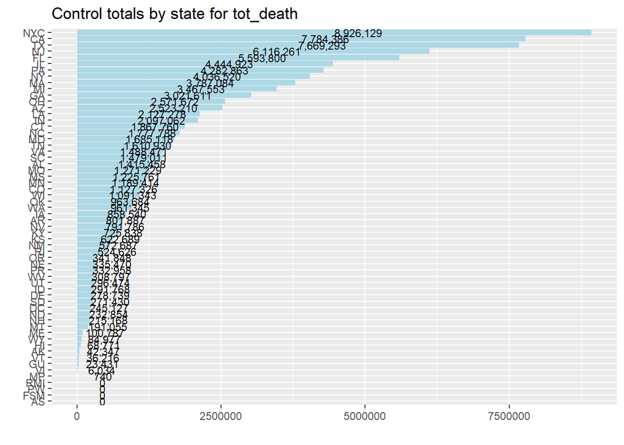

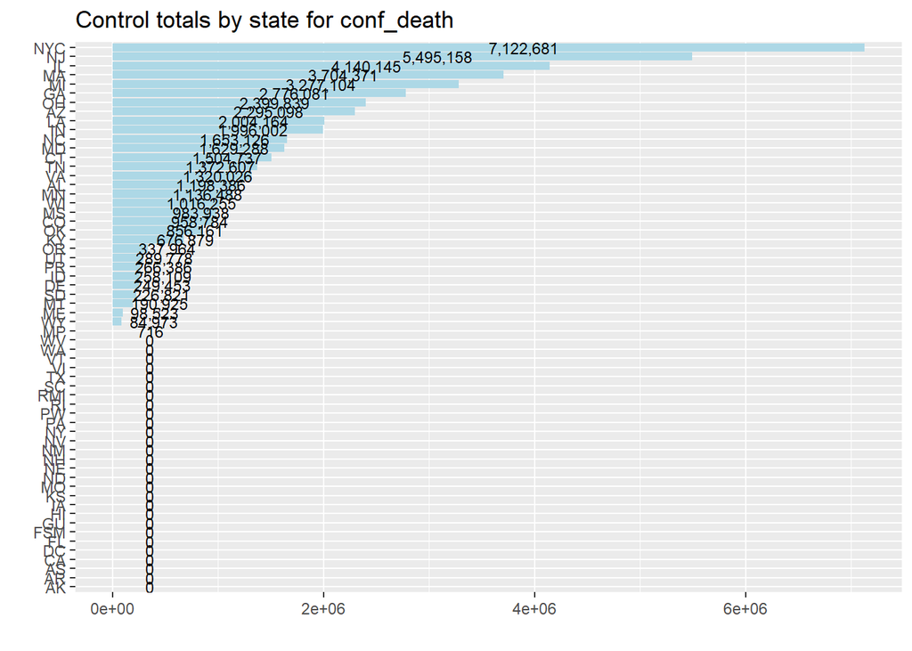

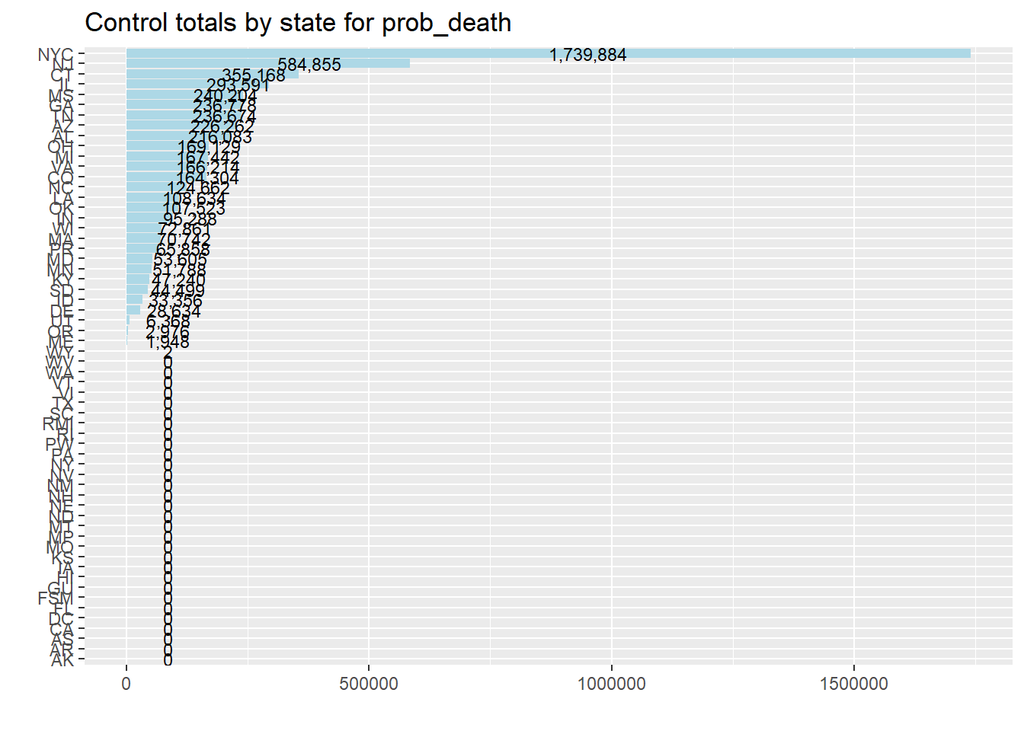

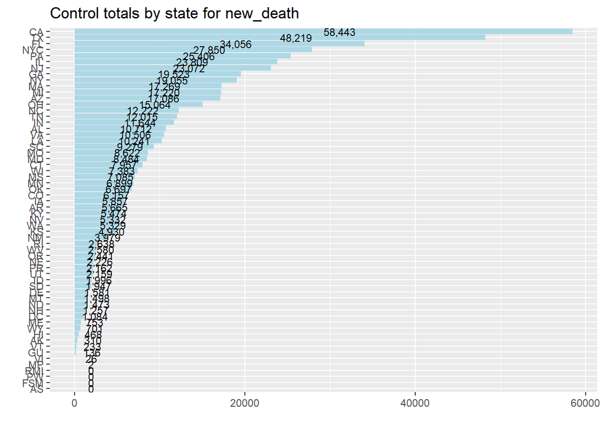

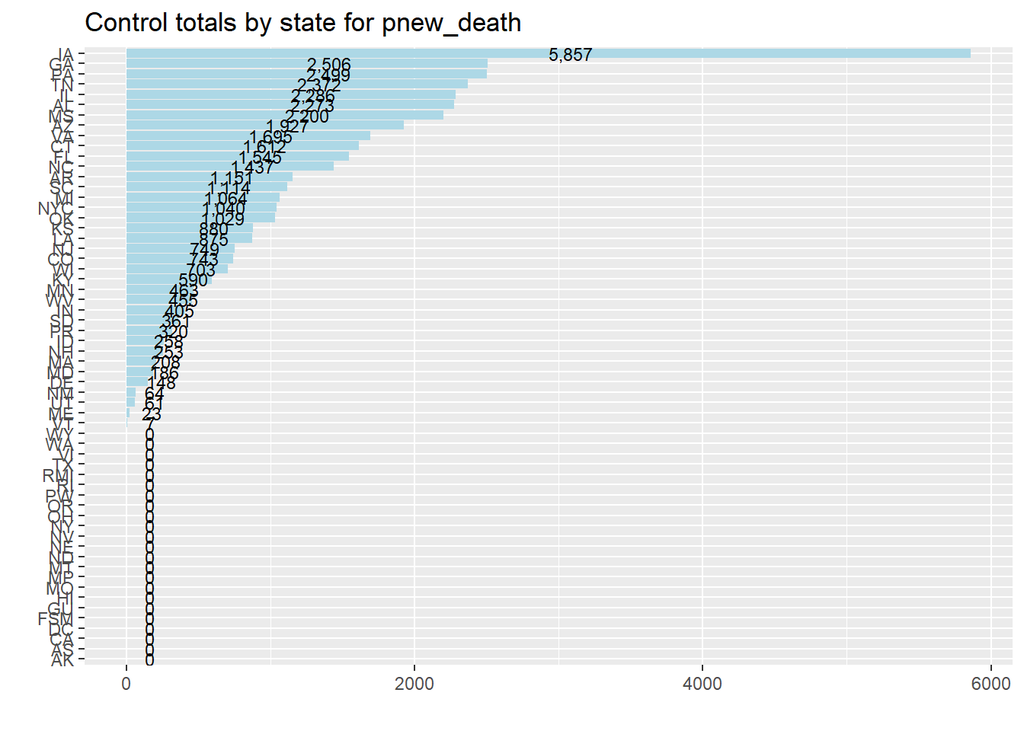

```r
# Get control totals by state for numeric fields
cdcControl <- cdcProcessed %>%
    group_by(state) %>%
    summarize_if(is.numeric, .funs=function(x) sum(x, na.rm=TRUE))

# Plot control totals by state for numeric fields
for (keyVar in names(cdcControl)[2:ncol(cdcControl)]) {
    p1 <- cdcControl %>%
        select_at(vars(all_of(c("state", keyVar)))) %>%
        purrr::set_names(c("state", "y")) %>%
        ggplot(aes(x=fct_reorder(state, y), y=y)) +
        geom_col(fill="lightblue") +
        geom_text(aes(y=y/2, label=format(y, big.mark=",")), size=3, hjust=0) +
        labs(x="", y="", title=paste0("Control totals by state for ", keyVar)) +
        coord_flip()
    print(p1)
}
```

Not every state reports on every metric. In particular, some jurisdictions break cases and deaths in to probable and confirmed while others do not. All states appear to report both total (cumulative) and new case. Comparisons of these fields are run, since restatements of history can lead to total and cumsum(new) being different:

```r
# Check for alignment of total and sum(new)
cdcMism <- cdcProcessed %>%
    arrange(state, date) %>%
    group_by(state) %>%
    mutate(ck_tot_case=cumsum(ifelse(is.na(new_case), 0, new_case)),
           ck_tot_death=cumsum(ifelse(is.na(new_death), 0, new_death))
           ) %>%
    select(date, state, tot_cases, ck_tot_case, tot_death, ck_tot_death, everything()) %>%
    mutate(mism_case=tot_cases != ck_tot_case, mism_death=tot_death != ck_tot_death) %>%
    group_by(state) %>%
    summarize(mism_case=sum(mism_case), mism_death=sum(mism_death), .groups="drop") %>%
    filter(mism_death > 0 | mism_case > 0) %>%
    arrange(-mism_case, -mism_death)
cdcMism
```

```
## # A tibble: 15 x 3
##    state mism_case mism_death
##    <chr>     <int>      <int>
##  1 TX          163          0
##  2 AL           41          0
##  3 MN           35         35
##  4 CA           34         47
##  5 MT            4          4
##  6 AZ            4          0
##  7 IN            1         68
##  8 NYC           0        363
##  9 NJ            0        292
## 10 OH            0         60
## 11 WV            0         32
## 12 MI            0         31
## 13 KY            0         26
## 14 MS            0         19
## 15 NC            0         19
```

Many states have data that are aligned throughout. In some states, there are differences between the total and new fields that should be explored further. A function is written to assess mismatches in the data:

```r
# Function to report totals and plot trends by state
assessMismatch <- function(keyStates,
                           keyMetric="cases",
                           df=cdcProcessed
                           ) {

    # FUNCTION ARGUMENTS
    # keyStates: states to be explored for differences
    # keyMetric: metric to be explored
    # df: the data frame containing data by state-date

    # Create a main database for comparisons
    dfUse <- cdcProcessed %>%
        arrange(state, date) %>%
        group_by(state) %>%
        mutate(ck_tot_case=cumsum(ifelse(is.na(new_case), 0, new_case)),
               ck_tot_death=cumsum(ifelse(is.na(new_death), 0, new_death)),
               d_cases=ck_tot_case-tot_cases,
               d_deaths=ck_tot_death-tot_death
               ) %>%
        select(date,
               state,
               cases=tot_cases,
               ck_cases=ck_tot_case,
               d_cases,
               deaths=tot_death,
               ck_deaths=ck_tot_death,
               d_deaths,
               everything()
               )

    # Show the discrepancies in the final data for each state
    dfUse %>%
        filter(state %in% all_of(keyStates)) %>%
        group_by(state) %>%
        filter(row_number()==n()) %>%
        select(date, state, cases, ck_cases, d_cases, deaths, ck_deaths, d_deaths) %>%
        print()

    # Create plot of metric evolution
    dfPlot <- dfUse %>%
        filter(state %in% all_of(keyStates)) %>%
        select(date, state, cases, ck_cases, d_cases, deaths, ck_deaths, d_deaths) %>%
        pivot_longer(-c(date, state)) %>%
        filter(str_detect(name, keyMetric))
    p1 <- dfPlot %>%
        filter(!str_detect(name, "d_")) %>%
        mutate(useName=ifelse(str_detect(name, "ck_"), "cumsum(new)", "reported total")) %>%
        ggplot(aes(x=date, y=value)) +
        geom_line(aes(group=useName, color=useName)) +
        labs(x="",
             y="Cumulative reported",
             title=paste0("Discrepancies in cumulative total ", keyMetric)
             ) +
        scale_color_discrete("Source") +
        facet_wrap(~state, scales="free_y")
    print(p1)
    p2 <- dfPlot %>%
        filter(str_detect(name, "d_")) %>%
        ggplot(aes(x=date, y=value)) +
        geom_line(aes(group=state, color=state)) +
        labs(x="",
             y="Cumulative discrepancy",
             title=paste0("Discrepancies in cumulative total ", keyMetric)
             ) +
        scale_color_discrete("State")
    print(p2)

}
```

The function can then be applied to the case and death data with mismatches:

```r
assessMismatch(keyStates=cdcMism %>% filter(mism_case > 0) %>% pull(state), keyMetric="cases")
```

```
## # A tibble: 7 x 8
## # Groups:   state [7]
##   date       state   cases ck_cases d_cases deaths ck_deaths d_deaths
##   <date>     <chr>   <dbl>    <dbl>   <dbl>  <dbl>     <dbl>    <dbl>
## 1 2021-04-12 AL     519071   512950   -6121  10712     10712        0
## 2 2021-04-12 AZ     850236   849611    -625  17086     17086        0
## 3 2021-04-12 CA    3602827  3599149   -3678  59249     58443     -806
## 4 2021-04-12 IN     699823   699538    -285  13151     11644    -1507
## 5 2021-04-12 MN     544046   543155    -891   7037      6899     -138
## 6 2021-04-12 MT     106253   106181     -72   1524      1498      -26
## 7 2021-04-12 TX    2819529  2749901  -69628  48219     48219        0
```

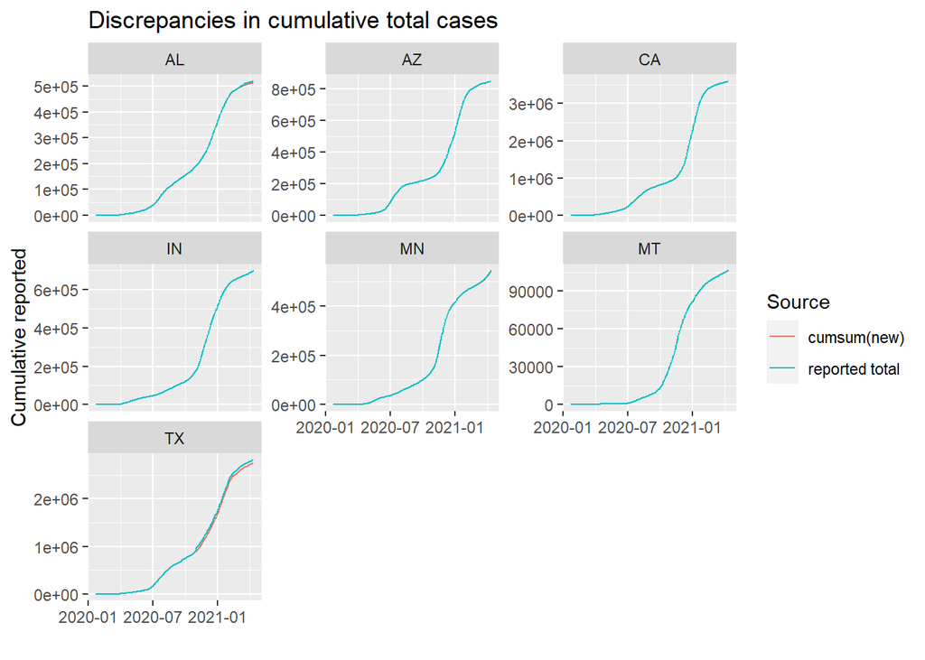

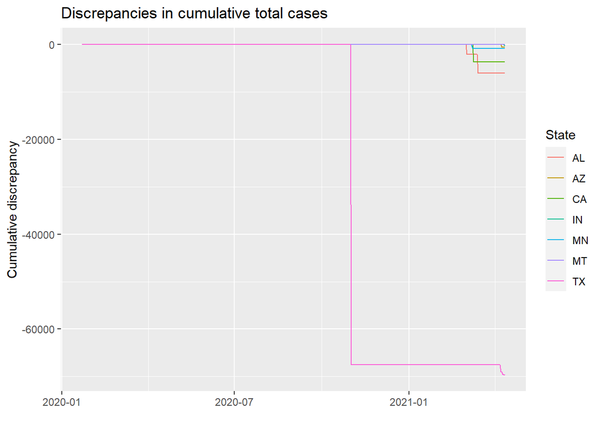

```r
assessMismatch(keyStates=cdcMism %>% filter(mism_death > 0) %>% pull(state), keyMetric="deaths")
```

```
## # A tibble: 12 x 8
## # Groups:   state [12]
##    date       state   cases ck_cases d_cases deaths ck_deaths d_deaths
##    <date>     <chr>   <dbl>    <dbl>   <dbl>  <dbl>     <dbl>    <dbl>
##  1 2021-04-12 CA    3602827  3599149   -3678  59249     58443     -806
##  2 2021-04-12 IN     699823   699538    -285  13151     11644    -1507
##  3 2021-04-12 KY     433352   433352       0   6257      5474     -783
##  4 2021-04-12 MI     830957   830957       0  17576     17220     -356
##  5 2021-04-12 MN     544046   543155    -891   7037      6899     -138
##  6 2021-04-12 MS     307836   307836       0   7119      7085      -34
##  7 2021-04-12 MT     106253   106181     -72   1524      1498      -26
##  8 2021-04-12 NC     935061   935061       0  12290     12222      -68
##  9 2021-04-12 NJ     955073   955073       0  24896     23072    -1824
## 10 2021-04-12 NYC    892028   892028       0  31909     27850    -4059
## 11 2021-04-12 OH    1041389  1041389       0  18827     15064    -3763
## 12 2021-04-12 WV     146462   146462       0   2745      2580     -165
```

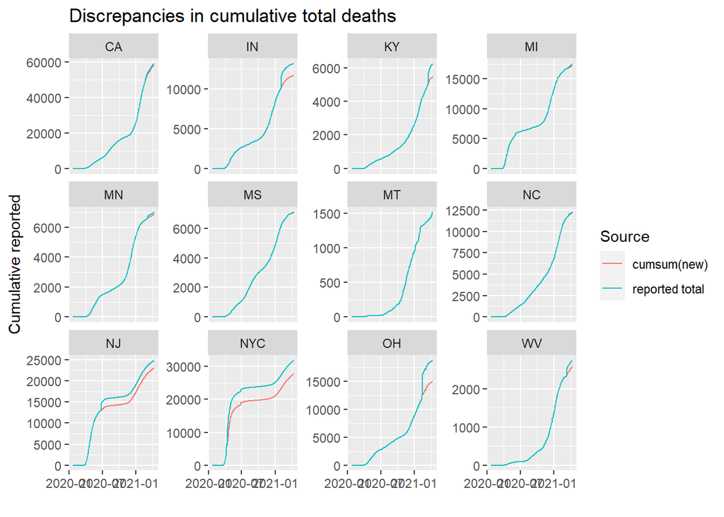

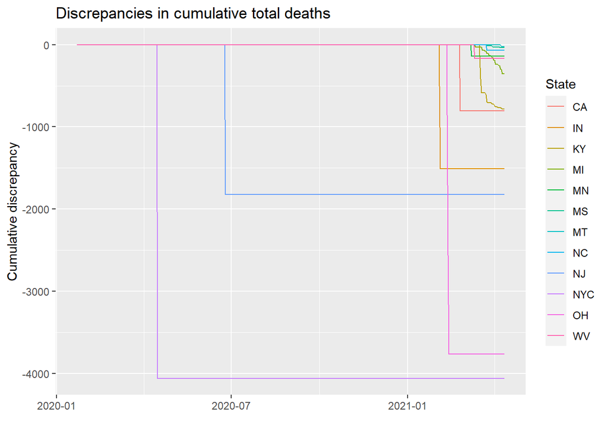

The mismathes appear to arise at discrete points in time, likely reflecting a reclassification of many previous cases and deaths. The total field is always greater than or equal to the sum of the new field. This sugests using ‘new’ for shape of the curve and ‘total’ for overall disease burden.

A function is then written to rename and split columns appropriately:

```r
# Create list of expected variables and renames (NA means keep as-is)
cdcVarNames <- c("date"=NA,
                 "state"=NA,
                 "tot_cases"=NA,
                 "conf_cases"=NA,
                 "prob_cases"=NA,
                 "new_case"="new_cases",
                 "pnew_case"="pnew_cases",
                 "tot_death"="tot_deaths",
                 "conf_death"="conf_deaths",
                 "prob_death"="prob_deaths",
                 "new_death"="new_deaths",
                 "pnew_death"="pnew_deaths",
                 "bool_c_cases"="bool_cases",
                 "bool_c_deaths"="bool_deaths"
                 )

# Function to rename variables, split, and pivot for easier analysis
renamePivotProcessed <- function(df,
                                 selectRename=cdcVarNames
                                 ) {

    # FUNCTION ARGUMENTS
    # df: a processed CDC data file
    # selectRename: a list of variable -> new name (NA means keep as-is) as c('original'='new')

    # Check alignment of variables in df and selectRename
    dfNames <- names(df)
    selNames <- names(selectRename)

    # Create the vector of renamed variables after selection
    selRenames <- unname(selectRename[selNames])
    selRenames[is.na(selRenames)] <- selNames[is.na(selRenames)]

    # Names in one but not the other
    cat("\n*** Variables that will be dropped (not in selectRename vector) include:",
        setdiff(dfNames, selNames),
        sep="\n"
        )
    cat("\n\n*** Variables passed in selectRename that are not in the data include:",
        setdiff(selNames, dfNames),
        sep="\n"
        )

    # Select the key variables and rename
    df <- df %>%
        select_at(vars(all_of(selNames))) %>%
        purrr::set_names(selRenames)

    # Pivot and separate the data, keeping unique by date-state
    # Requires that selectRename have every variable as modifier_type
    df <- df %>%
        pivot_longer(-c(date, state)) %>%
        tidyr::separate(name, into=c("modifier", "metric"), sep="_")

    # Summary NA statistics of the new dataset
    cat("\nSummary statistics for processed and pivoted data\n")
    df %>%
        group_by(modifier, metric) %>%
        summarize(n=n(), nna=sum(is.na(value)), sum=sum(value, na.rm=TRUE), .groups="drop") %>%
        print()
    cat("\n")

    # Return the data frane
    df

}
```

The function is applied to create cdcPivotLong:

```r
cdcPivotLong <- renamePivotProcessed(cdcProcessed)
```

```
##
## *** Variables that will be dropped (not in selectRename vector) include:
## submission_date
## created_at
## consent_cases
## consent_deaths
## creation_date
##
##
## *** Variables passed in selectRename that are not in the data include:
##
##
## Summary statistics for processed and pivoted data
## # A tibble: 12 x 5
##    modifier metric     n   nna        sum
##    <chr>    <chr>  <int> <int>      <dbl>
##  1 bool     cases  26820  4917      14722
##  2 bool     deaths 26820  4023      15198
##  3 conf     cases  26820 14842 2067083705
##  4 conf     deaths 26820 14478   51520966
##  5 new      cases  26820     0   30995591
##  6 new      deaths 26820     0     546212
##  7 pnew     cases  26820  4923    3328224
##  8 pnew     deaths 26820  5102      41359
##  9 prob     cases  26820 14843  230283006
## 10 prob     deaths 26820 14478    5712572
## 11 tot      cases  26820     0 4503152844
## 12 tot      deaths 26820     0   96207327
```

```r
glimpse(cdcPivotLong)
```

```
## Rows: 321,840
## Columns: 5
## $ date     <date> 2021-01-01, 2021-01-01, 2021-01-01, 2021-01-01, 2021-01-0...
## $ state    <chr> "FL", "FL", "FL", "FL", "FL", "FL", "FL", "FL", "FL", "FL"...
## $ modifier <chr> "tot", "conf", "prob", "new", "pnew", "tot", "conf", "prob...
## $ metric   <chr> "cases", "cases", "cases", "cases", "cases", "deaths", "de...
## $ value    <dbl> 1300528, NA, NA, 0, 6063, 21673, NA, NA, 0, 7, 0, 0, 7145,...
```

Next steps are to combine the NYS/NYC data as NY and to filter to the states and DC. A function is written to combine states (will be applied only to NY and NYC for these data):

```r
# Function to combine states
combineStates <- function(df,
                          mapper=comboStates,
                          sortBy=c("date", "state", "modifier", "metric"),
                          boolMod=c("bool")
                          ) {

    # FUNCTION ARGUMENTS:
    # df: a data frame resulting from renamePivotProcessed() that includes date-state-modifier-metric-value
    # mapper: a vector listing the states to be remapped
    # sortBy: order that the resulting file should be sorted (and unique) by
    # boolMod: modifier indicating value is a boolean rather than number (cannot be summed)

    # Split the file in to stand-alone and combined
    df <- df %>%
        mutate(combined=state %in% names(mapper))
    dfAlone <- df %>% filter(!combined)
    dfCombo <- df %>% filter(combined)

    # Process the combined file to give it the new state name
    # Group by the final sorting variables
    dfCombo <- dfCombo %>%
        mutate(state=unname(comboStates[state])) %>%
        group_by_at(vars(all_of(sortBy))) %>%
        arrange_at(vars(all_of(sortBy)))

    # Numeric variables should be summed, with NA+NA=NA and NA+number=number
    specNASum <- function(x) if (any(!is.na(x))) sum(x, na.rm=TRUE) else NA

    # Sum the value field, leave the combined field as-is
    dfCombo <- dfCombo %>%
        summarize(value=specNASum(value), combined=first(combined), .groups="drop")

    # Boolean variables should be output as NA since there is no sensible combining based on what it means
    dfCombo <- dfCombo %>%
        mutate(value=ifelse(modifier %in% all_of(boolMod), NA, value))

    # Combine the data, sort, check for uniqueness, and return
    dfAll <- bind_rows(dfCombo, dfAlone) %>%
        arrange_at(vars(all_of(sortBy)))
    if (nrow(distinct(dfAll %>% select_at(vars(all_of(sortBy))))) != nrow(dfAll)) stop("\nRow mismatch\n")
    dfAll

}
```

The function is then applied to the cdcPivotLong data:

```r
# List of states to be changed
# Also include any state that is mapped to itself with some other state mapping to it
# Format is 'currentState'='combinedState'
comboStates <- c("NYC"="NY",
                 "NY"="NY"
                 )

# Run function
cdcAnalysis <- combineStates(cdcPivotLong)

# Check for prevalenece of NA by metric-modifier
cdcAnalysis %>%
    group_by(metric, modifier) %>%
    summarize(sumValue=sum(value, na.rm=TRUE), n=n(), nna=sum(is.na(value)), nComb=sum(combined))
```

```
## # A tibble: 12 x 6
## # Groups:   metric [2]
##    metric modifier   sumValue     n   nna nComb
##    <chr>  <chr>         <dbl> <int> <int> <int>
##  1 cases  bool          14275 26373  5364   447
##  2 cases  conf     2067083705 26373 14395   447
##  3 cases  new        30995591 26373     0   447
##  4 cases  pnew        3328224 26373  4835   447
##  5 cases  prob      230283006 26373 14396   447
##  6 cases  tot      4503152844 26373     0   447
##  7 deaths bool          14751 26373  4470   447
##  8 deaths conf       51520966 26373 14031   447
##  9 deaths new          546212 26373     0   447
## 10 deaths pnew          41359 26373  5014   447
## 11 deaths prob        5712572 26373 14031   447
## 12 deaths tot        96207327 26373     0   447
```

The fields for tot/new by cases/deaths appear appropriate for further usage. Next steps are to compare the totals to existing data from the CTP (final date 2021-03-07).

The final CTP data are pulled, with cumulative data through 2021-03-07 calculated. Cumulative data through 2021-03-07 from the CDC file are also extracted:

```r
# Read in existing data from CTP
ctp_hier6_210401 <- readFromRDS("ctp_hier6_210401")

# Totals through 2021-03-07 for CTP (final date of collection)
ctp_cum_210307 <- ctp_hier6_210401$dfFiltered %>%
    group_by(state) %>%
    summarize_if(is.numeric, sum, na.rm=TRUE) %>%
    pivot_longer(-c(state), names_to="metric") %>%
    mutate(modifier="ctp") %>%
    select(state, modifier, metric, value, everything())
ctp_cum_210307
```

```
## # A tibble: 204 x 4
##    state modifier metric   value
##    <chr> <chr>    <chr>    <dbl>
##  1 AK    ctp      cases    56886
##  2 AK    ctp      deaths     305
##  3 AK    ctp      hosp     17804
##  4 AK    ctp      tests  1731620
##  5 AL    ctp      cases   499819
##  6 AL    ctp      deaths   10148
##  7 AL    ctp      hosp    404951
##  8 AL    ctp      tests  2323788
##  9 AR    ctp      cases   324818
## 10 AR    ctp      deaths    5319
## # ... with 194 more rows
```

```r
# Totals through 2021-03-07 for CDC (to match CTP data)
# Uses final tot-cases, final tot-deaths, cumsum new-cases, cumsum new-deaths
cdc_cum_210307 <- cdcAnalysis %>%
    filter(date <= as.Date("2021-03-07"),
           metric %in% c("cases", "deaths"),
           modifier %in% c("new", "tot"),
           state %in% c(state.abb, "DC")
           ) %>%
    pivot_wider(c(state, date, metric), names_from="modifier", values_from="value") %>%
    group_by(state, metric) %>%
    summarize(new=sum(new, na.rm=TRUE), tot=last(tot, order_by=date), .groups="drop") %>%
    pivot_longer(-c(state, metric), names_to="modifier") %>%
    select(state, modifier, metric, value, everything())
cdc_cum_210307
```

```
## # A tibble: 204 x 4
##    state modifier metric  value
##    <chr> <chr>    <chr>   <dbl>
##  1 AK    new      cases   56886
##  2 AK    tot      cases   56886
##  3 AK    new      deaths    301
##  4 AK    tot      deaths    301
##  5 AL    new      cases  497705
##  6 AL    tot      cases  499819
##  7 AL    new      deaths  10148
##  8 AL    tot      deaths  10148
##  9 AR    new      cases  324818
## 10 AR    tot      cases  324818
## # ... with 194 more rows
```

Next steps are to write a function to pull a specific metric and plot the differences in a ‘base’ modifier and any other values for modifier.

A function is written to compare data from different sources:

```r
# Function to assess variables new_x, tot_x, and x for percentage differences
checkStateCompare <- function(...,
                              met="cases",
                              baseModifier="ctp"
                              ) {

    # FUNCTION ARGUMENTS:
    # ...: one or more data frames of the form state-modifier-metric-value
    # met: the metric to be used, "cases" or "deaths"
    # baseModifier: value of the modifier field that signifies the baseline for comparison

    # Bind the data frames, and calculate as a percentage of the "base" modifier
    df <- bind_rows(...) %>%
        filter(metric %in% all_of(met)) %>%
        arrange(state, modifier) %>%
        group_by(state) %>%
        mutate(pct_of=value/sum(ifelse(modifier==all_of(baseModifier), value, 0))) %>%
        ungroup()

    # Plot the percentage differences for fields other than reference
    p1 <- df %>%
        filter(modifier != all_of(baseModifier)) %>%
        ggplot(aes(x=fct_reorder(state, pct_of),
                   y=pct_of,
                   color=modifier
                   )
               ) +
        geom_point() +
        coord_flip() +
        labs(x="",
             y=paste0("Reported ", met, " as function of baseline data from ", baseModifier),
             title=paste0("Comparison to baseline data for ", met)
             ) +
        scale_color_discrete("Comparison metric") +
        geom_hline(yintercept=1, lty=2)
    print(p1)

    # Return the data frame
    df

}
```

The function can then be applied to the cases and deaths data:

```r
# Run comparisons for cases and deaths
caseCompare <- checkStateCompare(ctp_cum_210307, cdc_cum_210307, met="cases")
```

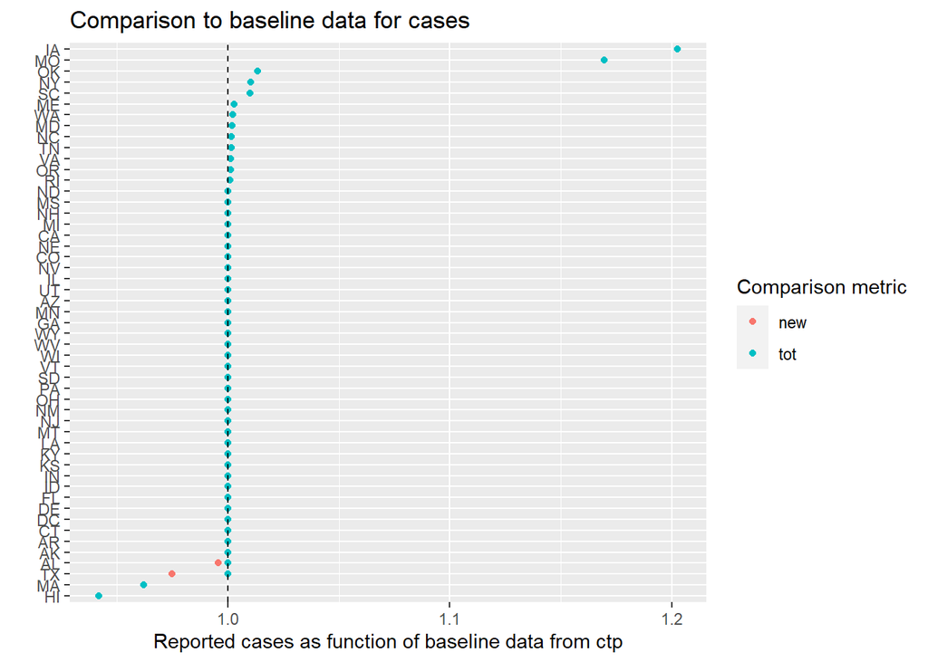

```r
deathCompare <- checkStateCompare(ctp_cum_210307, cdc_cum_210307, met="deaths")
```

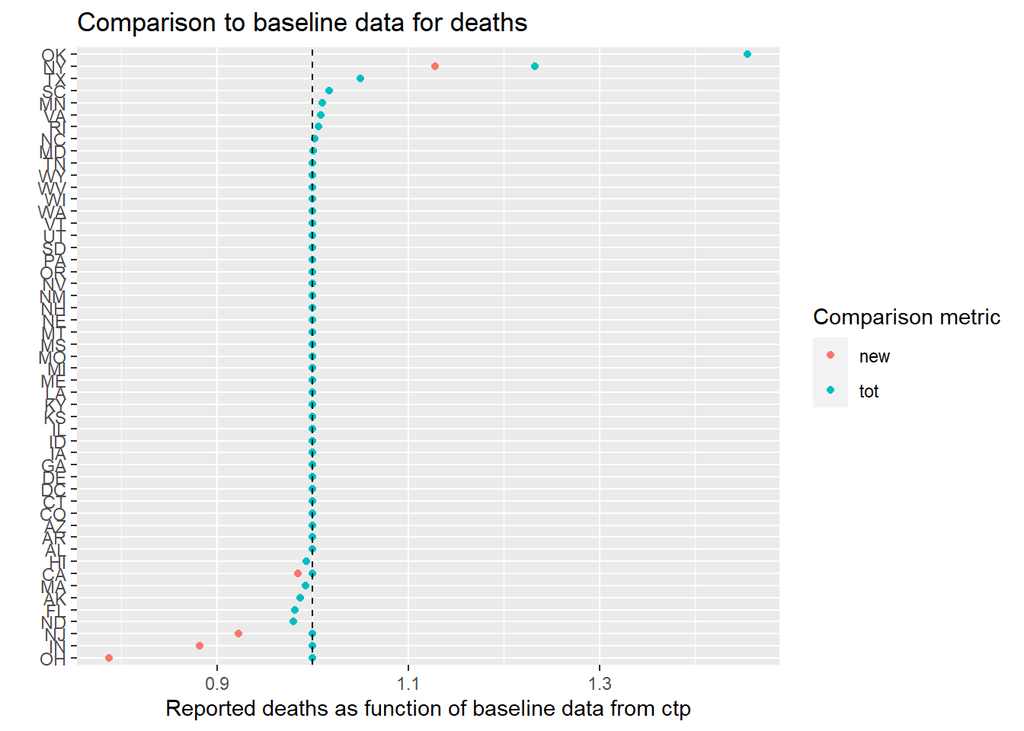

```r
# Print cases and deaths that are at least 3% different
caseCompare %>%
    filter(abs(1-pct_of) >= 0.03)
```

```
## # A tibble: 8 x 5
##   state modifier metric  value pct_of
##   <chr> <chr>    <chr>   <dbl>  <dbl>
## 1 HI    new      cases   27031  0.942
## 2 HI    tot      cases   27031  0.942
## 3 IA    new      cases  339574  1.20
## 4 IA    tot      cases  339574  1.20
## 5 MA    new      cases  568979  0.962
## 6 MA    tot      cases  568979  0.962
## 7 MO    new      cases  562129  1.17
## 8 MO    tot      cases  562129  1.17
```

```r
deathCompare %>%
    filter(abs(1-pct_of) >= 0.03)
```

```
## # A tibble: 9 x 5
##   state modifier metric value pct_of
##   <chr> <chr>    <chr>  <dbl>  <dbl>
## 1 IN    new      deaths 11230  0.882
## 2 NJ    new      deaths 21750  0.923
## 3 NY    new      deaths 44045  1.13
## 4 NY    tot      deaths 48104  1.23
## 5 OH    new      deaths 13893  0.787
## 6 OK    new      deaths  6598  1.46
## 7 OK    tot      deaths  6598  1.46
## 8 TX    new      deaths 46689  1.05
## 9 TX    tot      deaths 46689  1.05
```

Data are well aligned between CTP and CDC as of 2021-03-07. Primary differences include:

- CDC reports significantly greater cases for Iowa (+20%) and Missouri (+17%)
- CDC reports modestly lower cases for Massachusetts (-4%) and Hawaii (-6%)
- CDC reports significantly more deaths for Oklahoma (+46%) and New York (+13% on sum of ‘new’, +23% on ’tot)
- CDC reports modestly more deaths for Texas (+5%)
- CDC reports significantly lower deaths for Indiana (-11% using ‘new’), Ohio (-21% using ‘new’), and New Jersey (-8% using ‘new’), though sums of ‘tot’ for these states appear well aligned to the CTP data

In general, the CDC ‘tot’ field appears well aligned to the cumulative totals from CTP, and can likely be used on a go-forward as a measure of cumulative disease impact in each state.

Next steps are to check the curve evolutions, particularly since states with differences in ‘new’ and ‘tot’ have large corrections all reported at once.

A function is written to compare the shapes of the curves. Curve shape will be assessed as the percentage distribution of ‘new’ cases and deaths by time:

```r
curvePercent <- function(df,
                         keyMetric,
                         keyModifiers=c("new", "ctp"),
                         dateMax=as.Date("2021-03-07")
                         ) {


    # FUNCTION ARGUMENTS:
    # df: the data frame containing date-state-modifier-metric-value

    # Filter for the metric and modifiers of interest and only through dateMax
    df <- df %>%
        filter(metric %in% all_of(keyMetric),
               modifier %in% all_of(keyModifiers),
               date <= all_of(dateMax)
               )

    # Calculate the cumulative percentage by date
    df <- df %>%
        mutate(value=ifelse(is.na(value), 0, value)) %>%
        arrange(date) %>%
        group_by(state, metric, modifier) %>%
        mutate(pct=cumsum(value)/sum(value)) %>%
        ungroup()

    # Pivot for percentages by state-date-metric
    df <- df %>%
        pivot_wider(c(state, date, metric), names_from="modifier", values_from="pct") %>%
        mutate_at(vars(all_of(keyModifiers)), .funs=function(x) ifelse(is.na(x), 0, x))

    # Calculate RMSE for each state-metric (assumes only two columns - can expand later)
    stateRMSE <- df %>%
        group_by(state, metric) %>%
        summarize(rmse=sqrt(mean((get(keyModifiers[1])-get(keyModifiers[2]))**2)), .groups="drop")

    # Create plots of RMSE by state
    p1 <- stateRMSE %>%
        ggplot(aes(x=fct_reorder(state, rmse), y=rmse)) +
        geom_point() +
        geom_text(aes(label=round(rmse, 3), y=rmse+0.00025), hjust=0, size=3) +
        coord_flip() +
        labs(x="",
             y="RMSE for cumulative percentage by date",
             title=paste0("Curve comparison for ", keyMetric)
             )
    print(p1)

    # Return the data frame
    df

}
```

The CTP data are formatted for use with the function, integrated with cdcPivotLong, and assessed:

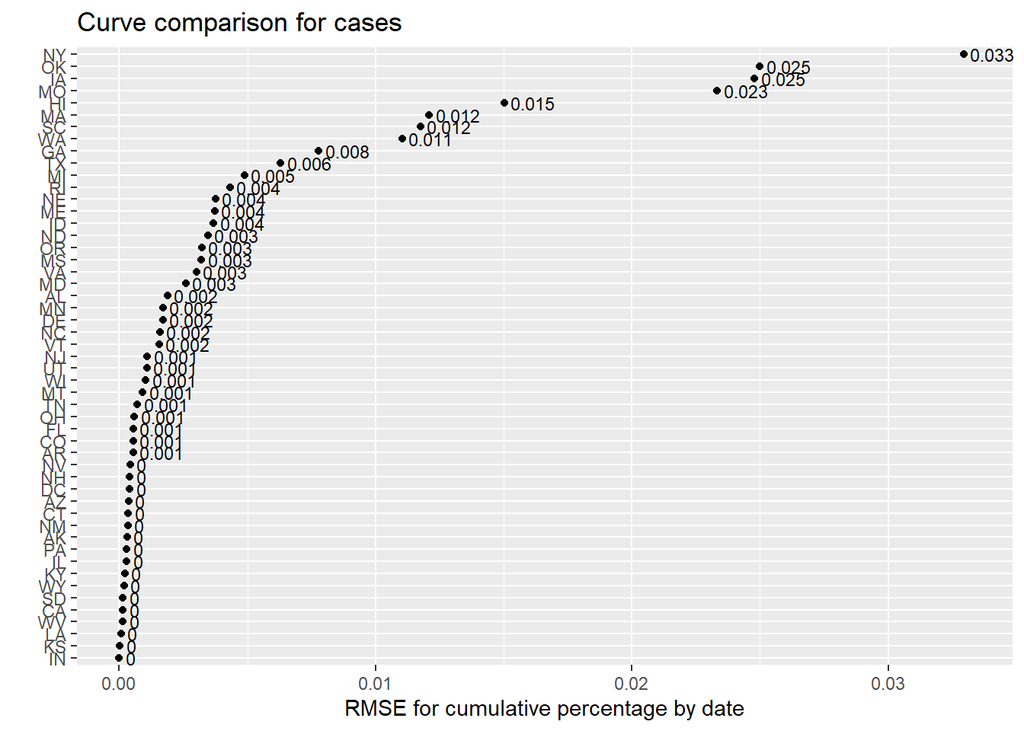

```r
fullPivotLong <- ctp_hier6_210401$dfFiltered %>%
    pivot_longer(-c(date, state), names_to="metric") %>%
    mutate(modifier="ctp") %>%
    bind_rows(cdcPivotLong) %>%
    filter(state %in% c(state.abb, "DC"))

curveCases <- curvePercent(fullPivotLong, keyMetric="cases")
```

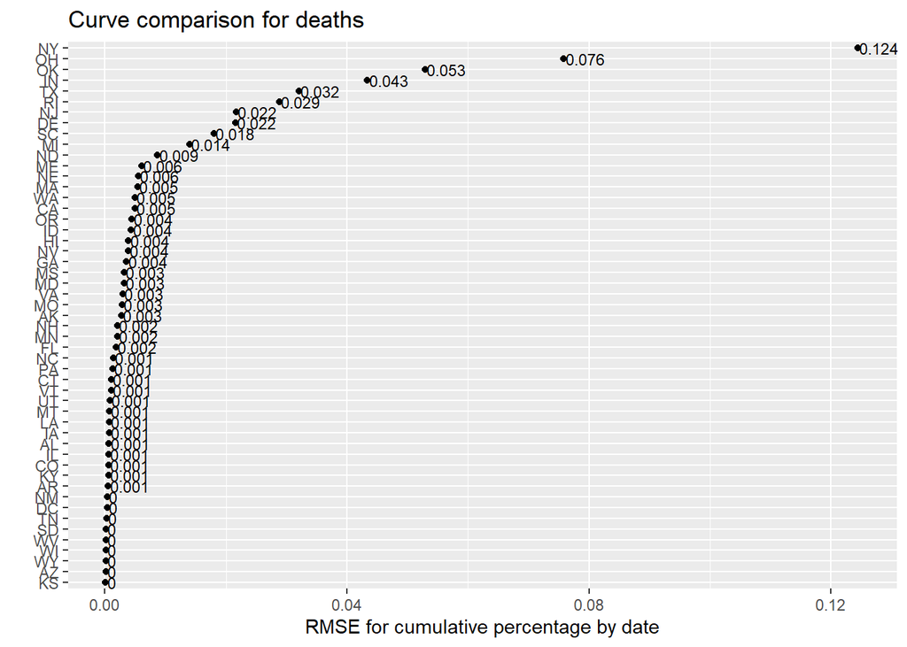

```r
curveDeath <- curvePercent(fullPivotLong, keyMetric="deaths")
```

Many of the same locales that have differences between the ‘new’ and ‘total’ fields in CDC also have differences in curve shape with CTP. Next steps are to explore some of the larger differences.

A function is written to explore curves for a speciic metric and set of states:

```r
exploreCurve <- function(df,
                         keyMetric=NULL,
                         keyStates=NULL
                         ) {

    # FUNCTION ARGUMENTS:
    # df: data frame containing state-date-metric-[1 column per metric type]
    # keyMetric: the metric to filter in column 'metric' (NULL means determine from data)
    # keyStates: the list of states to be plotted (NULL means pick the top 9 from data)

    # Get keyMetric if it is passed as NULL
    if (is.null(keyMetric)) {
        keyMetric <- df %>% count(metric) %>% arrange(-n) %>% head(1) %>% pull(metric)
        cat("\nKey metric will be: ", keyMetric)
    }

    # Get the numerical columns for plotting
    colPlot <- df %>% select_if(is.numeric) %>% names()
    cat("\nColumns to be plotted will be: ", colPlot, "\n")

    # Get keyStates if not passed
    if (is.null(keyStates)) {
        keyStates <- df %>%
            filter(metric==all_of(keyMetric)) %>%
            group_by(state) %>%
            summarize(rmse=sqrt(mean((get(colPlot[1])-get(colPlot[2]))**2)), .groups="drop") %>%
            arrange(-rmse) %>%
            head(9) %>%
            pull(state)
        cat("States to be plotted will be: ", keyStates, "\n")
    }

    # Create faceted plots for the requested metrics
    dfPlot <- df %>%
        filter(metric==all_of(keyMetric), state %in% all_of(keyStates)) %>%
        select_at(vars(all_of(c("state", "date", colPlot)))) %>%
        mutate(state=factor(state, levels=keyStates)) %>%
        pivot_longer(-c("state", "date")) %>%
        arrange(state, name, date) %>%
        group_by(state, name) %>%
        mutate(delta=ifelse(row_number()==1, value, value-lag(value, 1)))
    p1 <- dfPlot %>%
        ggplot(aes(x=date, y=value)) +
        geom_line(aes(group=name, color=name)) +
        facet_wrap(~state) +
        labs(x="",
             y="Cumulative percentage of total recorded by date",
             title=paste0("Curve evolution by percentage for metric: ", keyMetric),
             subtitle="Cumulative"
             ) +
        scale_color_discrete("Data source")
    p2 <- dfPlot %>%
        ggplot(aes(x=date, y=delta)) +
        geom_line(aes(group=name, color=name)) +
        facet_wrap(~state, scales="free_y") +
        labs(x="",
             y="Incremental percentage of total recorded by date",
             title=paste0("Curve evolution by percentage for metric: ", keyMetric),
             subtitle="Incremental"
             ) +
        scale_color_discrete("Data source")
    print(p1)
    print(p2)

}
```

The routine is then run for cases and deaths, with a larger plotting area:

```
##
## Key metric will be:  cases
## Columns to be plotted will be:  ctp new
## States to be plotted will be:  NY OK IA MO HI MA SC WA GA
```

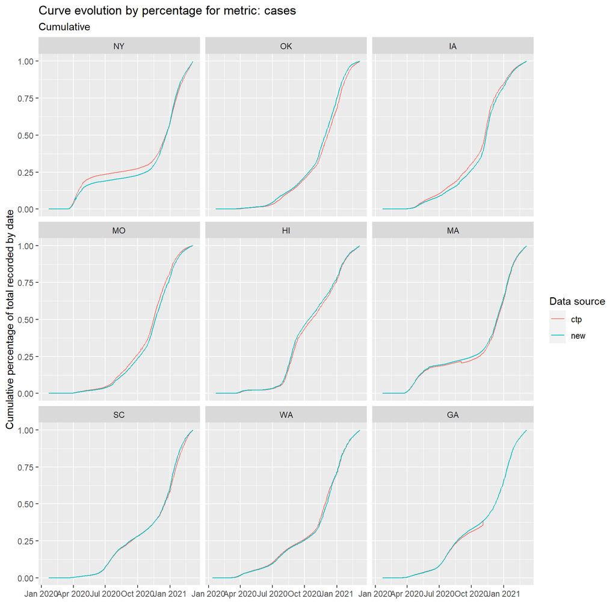

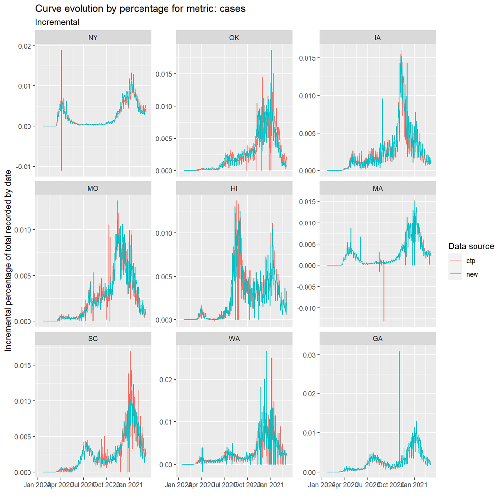

```r
exploreCurve(curveCases)
```

```
##
## Key metric will be:  deaths
## Columns to be plotted will be:  ctp new
## States to be plotted will be:  NY OH OK IN TX RI NJ DE SC
```

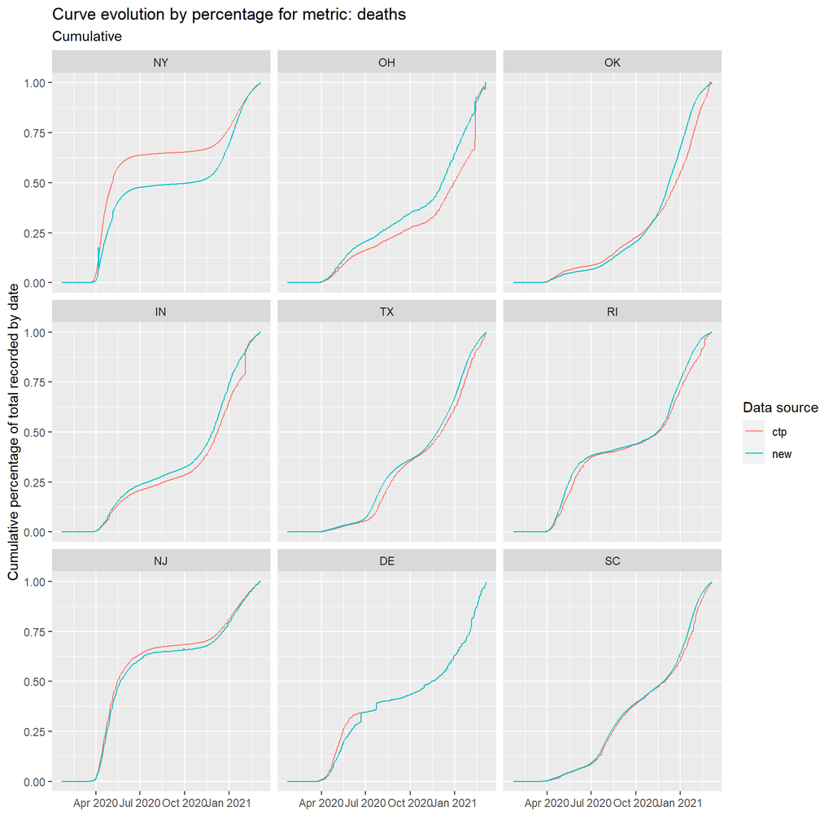

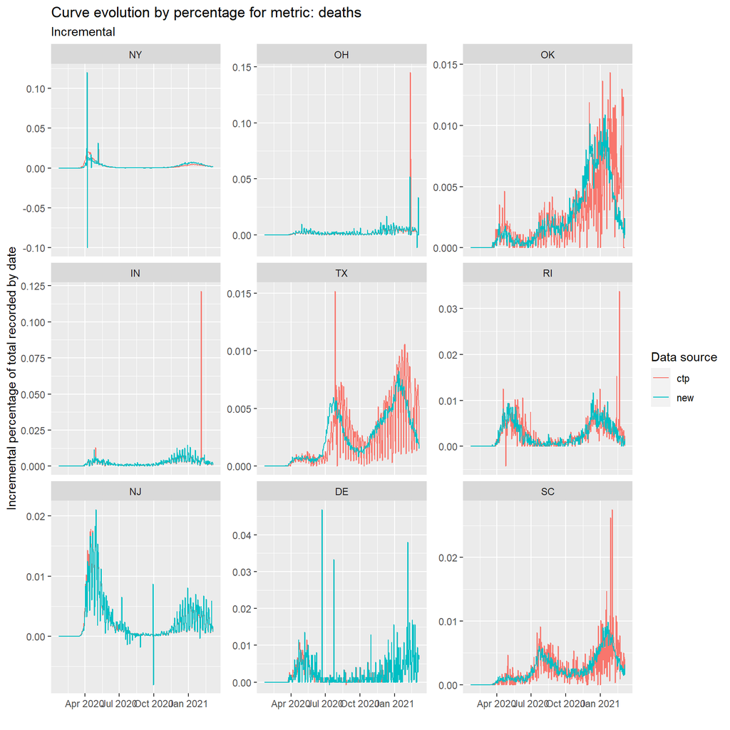

```r
exploreCurve(curveDeath)
```

Visually, the shapes of the case curves are nearly overlapping, and segments based using shape will likely be the same whether using CTP or CDC data. The shapes of the death curves vary meaningfully in NY and modestly in OH, OK, and IN. While the different curve evolutions are unlikely to drive different segments, it is worth keeping an eye on (particularly for NY).

Next steps are to adapt the CDC data and existing CTP code so they can be used together.

#### *Coding Steps for State Data*

The main function used previously is readRunCOVIDTrackingProject(), which performs multiple tasks:

STEP 1: Extracts a file of population by state (by default uses 2015 population from usmap::statepop)  
STEP 2a^: Downloads the latest data from COVID Tracking Project if requested  
STEP 2b^: Reads in data from a specified local file (may have just been downloaded in step 2a), and checks control total trends against a previous version of the file  
STEP 3^: Processed the loaded data file for keeping proper variables, dropping non-valid states, etc.  
STEP 4^: Adds per-capita metrics for cases, deaths, tests, and hospitalizations  
STEP 5: Adds existing clusters by state if passed as an argument to useClusters=, otherwise creates new segments based on user-defined parameters  
STEP 6^^: Creates assessment plots for the state-level clusters  
STEP 7^^: Creates consolidated plots of cases, hospitalizations, deaths, and tests  
STEP 8^^: Optionally, creates plots of cumulative burden by segments and by state  
STEP 9: Returns a list of key data frames, modeling objects, named cluster vectors, etc.

^ The user can instead specify a previously processed file and skip steps 2a, 2b, 3, and 4. The previously processed file needs to be formatted and filtered such that it can be used “as is”  
^^ The user can skip the segment-level assessments by setting skipAssessmentPlots=TRUE

The main function and the helper functions were previously updated to allow for using 2021 data. The main function is copied below and will eventually be adapted for CDC daily data:

```r
# Function to download/load, process, segment, and analyze data for CDC daily
# Needs to be updated
readRunCDCDaily <- function(thruLabel,
                            downloadTo=NULL,
                            readFrom=downloadTo,
                            compareFile=NULL,
                            dateChangePlot=FALSE,
                            dateMetricPrint=TRUE,
                            writeLog=NULL,
                            ovrwriteLog=TRUE,
                            dfPerCapita=NULL,
                            useClusters=NULL,
                            hierarchical=TRUE,
                            returnList=!hierarchical,
                            kCut=6,
                            reAssignState=vector("list", 0),
                            makeCumulativePlots=TRUE,
                            skipAssessmentPlots=FALSE,
                            ...
                            ) {

    # FUNCTION ARGUMENTS:
    # thruLabel: the label for when the data are through (e.g., "Aug 30, 2020")
    # donwloadTo: download the most recent CDC daily data to this location
    #             NULL means do not download any data
    # readFrom: location for reading in the CDC daily data (defaults to donwloadTo)
    # compareFile: name of the file to use for comparisons when reading in raw data (NULL means no comparison)
    # dateChangePlot: boolean, should changes in dates be captured as a plot rather than as a list?
    # dateMetricPrint: boolean, should the changes by date and metric be printed to the main log?
    # writeLog: name of a separate log file for capturing detailed data on changes between files
    #           NULL means no detailed data captured
    # ovrwriteLog: boolean, should the log file be overwritten and started again from scratch?
    # dfPerCapita: file can be passed directly, which bypasses the loading and processing steps
    # useClusters: file containing clusters by state (NULL means make the clusters from the data)
    # hierarchical: boolean, should hierarchical clusters be produced (if FALSE, will be k-means)?
    # returnList: boolean, should a list be returned or just the cluster object?
    #             refers to what is returned by clusterStates(); the main function always returns a list
    # kCut: number of segments when cutting the hierarchical tree
    # reAssignState: mapping file for assigning a state to another state's cluster
    #                format list("stateToChange"="stateClusterToAssign")
    # makeCumulativePlots: whether to make plots of cumulative metrics
    # skipAssessmentPlots: boolean to skip the plots for assessClusters()
    #                      especially useful if just exploring dendrograms or silhouette widths
    # ...: arguments to be passed to clusterStates(), will be used only if useClusters is NULL


    # STEP 1: Get state data
    stateData <- getStateData()

    # Helper function for glimpsing
    glimpseFile <- function(x, txt) {
        cat(txt)
        glimpse(x)
    }

    # STEPS 2-4 are run only if dfPerCapita does not exist
    if (is.null(dfPerCapita)) {

        # STEP 2a: Download latest CDC daily data (if requested)
        if (!is.null(downloadTo)) {
            downloadCOVIDbyState(fileName=downloadTo,
                                 api="https://api.covidtracking.com/v1/states/daily.csv"
                                 )
        }

        # STEP 2b: Read-in CDC Daily Data
        dfRaw <- readCOViDbyState(readFrom,
                                  checkFile=compareFile,
                                  dateChangePlot=dateChangePlot,
                                  dateMetricPrint=dateMetricPrint,
                                  writeLog=writeLog,
                                  ovrwriteLog=ovrwriteLog
                                  )
        if (is.null(writeLog)) glimpseFile(dfRaw, txt="\nRaw data file:\n")
        else capture.output(glimpseFile(dfRaw, txt="\nRaw data file:\n"), file=writeLog, append=TRUE)

        # STEP 3: Process the data so that it includes all requested key variables
        varsFilter <- c("date", "state", "positiveIncrease", "deathIncrease",
                        "hospitalizedCurrently", "totalTestResultsIncrease"
                        )
        dfFiltered <- processCVData(dfRaw,
                                    varsKeep=varsFilter,
                                    varsRename=c(positiveIncrease="cases",
                                                 deathIncrease="deaths",
                                                 hospitalizedCurrently="hosp",
                                                 totalTestResultsIncrease="tests"
                                    )
        )
        if (is.null(writeLog)) glimpseFile(dfFiltered, txt="\nFiltered data file:\n")
        else capture.output(glimpseFile(dfFiltered, txt="\nFiltered data file:\n"), file=writeLog, append=TRUE)

        # STEP 4: Convert to per capita
        dfPerCapita <- helperMakePerCapita(dfFiltered,
                                           mapVars=c("cases"="cpm", "deaths"="dpm",
                                                     "hosp"="hpm", "tests"="tpm"
                                           ),
                                           popData=stateData
        )
        if (is.null(writeLog)) glimpseFile(dfPerCapita, txt="\nPer capita data file:\n")
        else capture.output(glimpseFile(dfPerCapita, txt="\nPer capita data file:\n"),
                            file=writeLog,
                            append=TRUE
                            )

    } else {
        dfRaw <- NULL
        dfFiltered <- NULL
    }


    # STEP 5: Create the clusters (if they have not been passed)
    if (is.null(useClusters)) {
        # Run the clustering process
        clData <- clusterStates(df=dfPerCapita, hierarchical=hierarchical, returnList=returnList, ...)
        # If hierarchical clusters, cut the tree, otherwise use the output object directly
        if (hierarchical) {
            useClusters <- cutree(clData, k=kCut)
        } else {
            useClusters <- clData$objCluster$cluster
        }
        # If requested, manually assign clusters to the cluster for another state
        for (xNum in seq_len(length(reAssignState))) {
            useClusters[names(reAssignState)[xNum]] <- useClusters[reAssignState[[xNum]]]
        }

    }


    # STEP 5a: Stop the process and return what is available if skipAssessmentPlots is TRUE
    if (skipAssessmentPlots) {
        return(list(stateData=stateData,
                    dfRaw=dfRaw,
                    dfFiltered=dfFiltered,
                    dfPerCapita=dfPerCapita,
                    useClusters=useClusters,
                    plotData=NULL,
                    consolidatedPlotData=NULL,
                    clCum=NULL
                    )
               )
    }


    # STEP 6: Create the cluster assessments
    plotData <- assessClusters(useClusters,
                               dfState=stateData,
                               dfBurden=dfPerCapita,
                               thruLabel=thruLabel,
                               plotsTogether=TRUE
    )


    # STEP 7: Plot the consolidated metrics
    subT <- "Cases: new cases, Deaths: new deaths, Hosp: total in hospital (not new), Tests: new tests"
    consolidatedPlotData <- plotConsolidatedMetrics(plotData,
                                                    varMain=c("state", "cluster", "date", "pop",
                                                              "cases", "deaths", "hosp", "tests"
                                                    ),
                                                    subT=subT,
                                                    nrowPlot2=2
    )

    # STEP 8: Create cumulative metrics if requested
    if (makeCumulativePlots) {
        consPos <- consolidatedPlotData %>%
            ungroup() %>%
            select(state, cluster, date, name, vpm7) %>%
            arrange(state, cluster, date, name) %>%
            pivot_wider(-vpm7, names_from="name", values_from="vpm7") %>%
            mutate(pctpos=cases/tests) %>%
            pivot_longer(-c(state, cluster, date), values_to="vpm7") %>%
            filter(!is.na(vpm7))
        clCum <- makeCumulative(consPos)
        plotCumulativeData(clCum,
                           keyMetricp2="",
                           flagsp2="",
                           makep1=TRUE,
                           makep2=FALSE
        )
        plotCumulativeData(clCum,
                           keyMetricp2="deaths",
                           flagsp2=findFlagStates(clCum, keyMetricVal = "deaths")
        )
        plotCumulativeData(clCum,
                           keyMetricp2="cases",
                           flagsp2=findFlagStates(clCum, keyMetricVal = "cases")
        )
        plotCumulativeData(clCum,
                           keyMetricp2="tests",
                           flagsp2=findFlagStates(clCum, keyMetricVal = "tests")
        )
    } else {
        clCum <- NULL
    }


    # STEP 9: Return a list of the key data
    list(stateData=stateData,
         dfRaw=dfRaw,
         dfFiltered=dfFiltered,
         dfPerCapita=dfPerCapita,
         useClusters=useClusters,
         plotData=plotData,
         consolidatedPlotData=consolidatedPlotData,
         clCum=clCum
    )


}
```

The state data are downloaded and a per capita file created:

```r
# Function to extract and format key state data
getStateData <- function(df=readFromRDS("statePop2019"),
                         renameVars=c("stateAbb"="state", "NAME"="name", "pop_2019"="pop"),
                         keepVars=c("state", "name", "pop")
                         ) {

    # FUNCTION ARGUMENTS:
    # df: the data frame containing state data
    # renameVars: variables to be renamed, using named list with format "originalName"="newName"
    # keepVars: variables to be kept in the final file

    # Rename variables where appropriate
    names(df) <- ifelse(is.na(renameVars[names(df)]), names(df), renameVars[names(df)])

    # Return file with only key variables kept
    df %>%
        select_at(vars(all_of(keepVars)))

}

# Run getStateData() as a stand-alone
stateDataCDC <- getStateData()

# Create an analysis file, pivoted wider, for new and total cases/deaths
cdcFiltered <- cdcAnalysis %>%
    filter(metric %in% c("cases", "deaths"), modifier %in% c("new", "tot")) %>%
    mutate(key=paste(modifier, metric, sep="_")) %>%
    pivot_wider(c("date", "state"), names_from="key", values_from="value")


# Helper function to create per capita metrics
helperPerCapita <- function(df,
                            origVar,
                            newName,
                            byVar="state",
                            popVar="pop",
                            popData=stateData,
                            mult=1000000
                            ) {

    # FUNCTION ARGUMENTS:
    # df: the data frame currently being processed
    # origVar: the variables to be converted to per capita
    # newName: the new per capita variable name
    # byVar: the variable that will be merged by
    # popVar: the name of the population variable in the popData file
    # popData: the file containing the population data
    # mult: the multiplier, so that the metric is "per mult people"

    # Create the per capita variable
    df %>%
        inner_join(select_at(popData, vars(all_of(c(byVar, popVar)))), by=byVar) %>%
        mutate(!!newName:=mult*get(origVar)/get(popVar)) %>%
        select(-all_of(popVar))

}


# Helper function to create rolling aggregates
helperRollingAgg <- function(df,
                             origVar,
                             newName,
                             func=zoo::rollmean,
                             k=7,
                             fill=NA,
                             ...
                             ) {

    # FUNCTION ARGUMENTS:
    # df: the data frame containing the data
    # origVar: the original data column name
    # newName: the new variable column name
    # func: the function to be applied (zoo::rollmean will be by far the most common)
    # k: the periodicity (k=7 is rolling weekly data)
    # fill: how to fill leading.trailing data to maintain the same vector lengths
    # ...: any other arguments to be passed to func

    # Create the appropriate variable
    df %>%
        mutate(!!newName:=func(get(origVar), k=k, fill=fill, ...))

}


# Function to add per capita and rolling to the base data frame
helperMakePerCapita <- function(df,
                                mapVars=c("cases"="cpm", "deaths"="dpm"),
                                popData=stateData,
                                k=7
                                ) {

    # FUNCTION ARGUMENTS:
    # df: the initial data frame for conversion
    # mapVars: named vector of variables to be converted 'original name'='converted name'
    # k: the rolling time period to use

    # Create the variables for per capita
    for (origVar in names(mapVars)) {
        df <- df %>%
            helperPerCapita(origVar=origVar, newName=mapVars[origVar], popData=popData)
    }
    # Arrange the data by date in preparation for rolling aggregations
    df <- df %>%
        group_by(state) %>%
        arrange(date)

    # Create the rolling variables
    for (newVar in mapVars) {
        df <- df %>%
            helperRollingAgg(origVar=newVar, newName=paste0(newVar, k), k=k)
    }

    # Return the updated data frame, ungrouped
    df %>%
        ungroup()

}

# Convert to per capita
cdcPerCapita <- helperMakePerCapita(cdcFiltered,
                                    mapVars=c("new_cases"="cpm", "new_deaths"="dpm",
                                              "tot_cases"="tcpm", "tot_deaths"="tdpm"
                                              ),
                                    popData=stateDataCDC
                                    )
cdcPerCapita
```

```
## # A tibble: 22,797 x 14
##    date       state new_cases new_deaths tot_cases tot_deaths   cpm   dpm  tcpm
##    <date>     <chr>     <dbl>      <dbl>     <dbl>      <dbl> <dbl> <dbl> <dbl>
##  1 2020-01-22 AK            0          0         0          0     0     0     0
##  2 2020-01-22 AL            0          0         0          0     0     0     0
##  3 2020-01-22 AR            0          0         0          0     0     0     0
##  4 2020-01-22 AZ            0          0         0          0     0     0     0
##  5 2020-01-22 CA            0          0         0          0     0     0     0
##  6 2020-01-22 CO            0          0         0          0     0     0     0
##  7 2020-01-22 CT            0          0         0          0     0     0     0
##  8 2020-01-22 DC            0          0         0          0     0     0     0
##  9 2020-01-22 DE            0          0         0          0     0     0     0
## 10 2020-01-22 FL            0          0         0          0     0     0     0
## # ... with 22,787 more rows, and 5 more variables: tdpm <dbl>, cpm7 <dbl>,
## #   dpm7 <dbl>, tcpm7 <dbl>, tdpm7 <dbl>
```

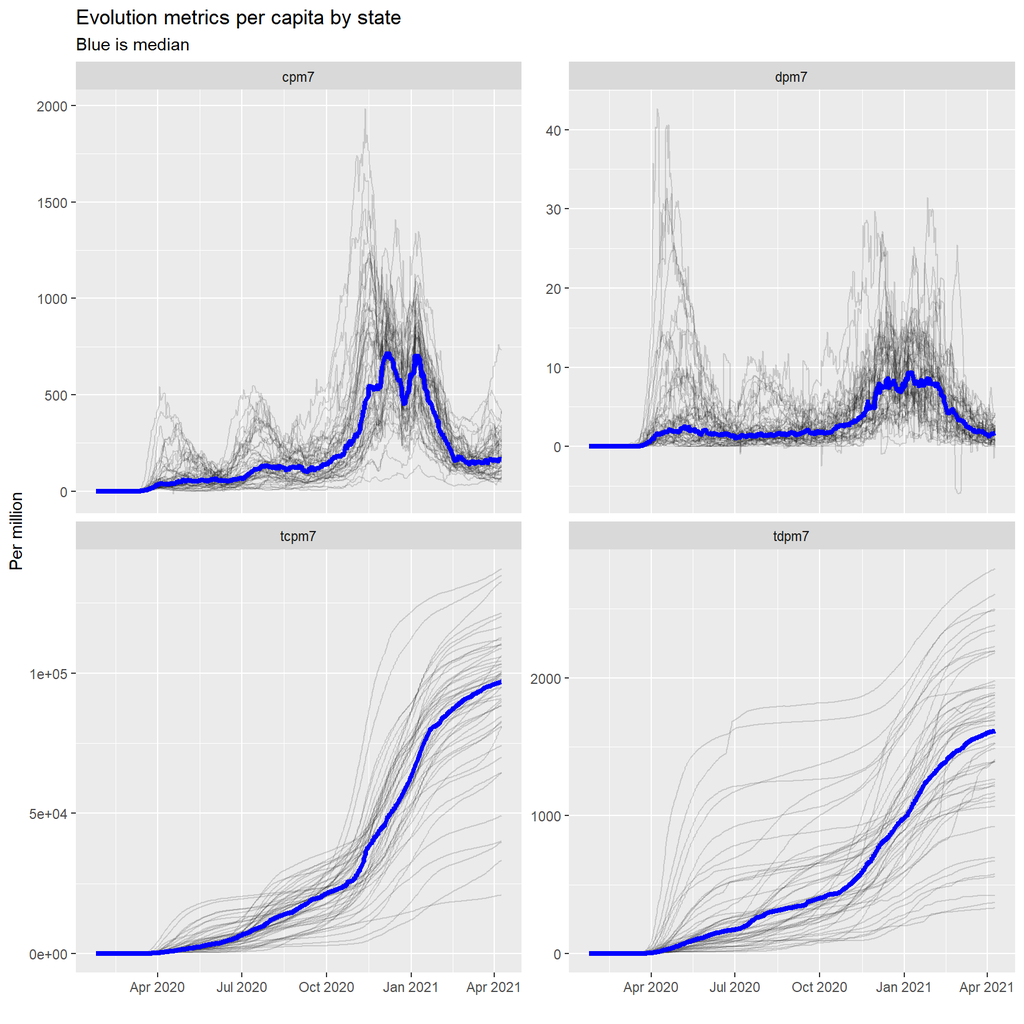

```r
cdcPerCapita %>%
    select(date, state, contains("7")) %>%
    pivot_longer(-c("date", "state")) %>%
    filter(!is.na(value)) %>%
    bind_rows(mutate(summarize(group_by(., date, name), value=median(value), .groups="drop"),
                     state="med"
                     )
              ) %>%
    ggplot(aes(x=date, y=value)) +
    geom_line(data=~filter(., state!="med"), aes(group=state), alpha=0.15) +
    geom_line(data=~filter(., state=="med"), aes(group=state), color="blue", size=1.5) +
    labs(x="", y="Per million", title="Evolution metrics per capita by state", subtitle="Blue is median") +
    facet_wrap(~name, scales="free_y")
```

Per capita data appear broadly as expected. Next steps are to update the segmentation and clustering algorithms. The function call is copied, with the function then updated:

```r
# Clustering code
# STEP 5: Create the clusters (if they have not been passed)
# if (is.null(useClusters)) {
#     # Run the clustering process
#     clData <- clusterStates(df=dfPerCapita, hierarchical=hierarchical, returnList=returnList, ...)
#     # If hierarchical clusters, cut the tree, otherwise use the output object directly
#     if (hierarchical) {
#         useClusters <- cutree(clData, k=kCut)
#     } else {
#         useClusters <- clData$objCluster$cluster
#     }
#     # If requested, manually assign clusters to the cluster for another state
#     for (xNum in seq_len(length(reAssignState))) {
#         useClusters[names(reAssignState)[xNum]] <- useClusters[reAssignState[[xNum]]]
#     }
# }

# Function to create an elbow plot for various numbers of clusters in the data
helperElbow <- function(mtx,
                        testCenters,
                        iter.max,
                        nstart,
                        silhouette=FALSE
                        ) {

    # FUNCTION ARGUMENTS:
    # mtx: a numeric matrix, or an object that can be coerced to a numeric matrix (no character fields)
    # testCenters: integer vector for the centers to be tested
    # iter.max: parameter passed to kmeans
    # nstart: parameter passed to kmeans
    # silhouette: whether to calculate the silhouette score

    # Create an object for storing tot.withinss and silhouetteScore
    totWithin <- vector("numeric", length(testCenters))
    silhouetteScore <- vector("numeric", length(testCenters))

    # Create the distancing data (required for silhouette score)
    if (silhouette) distData <- dist(mtx)

    # Run k-means for every value in testCenters, and store $tot.withinss (and silhouetteScore, if requested)
    n <- 1
    for (k in testCenters) {
        km <- kmeans(mtx, centers=k, iter.max=iter.max, nstart=nstart)
        totWithin[n] <- km$tot.withinss
        if (silhouette & (k > 1)) silhouetteScore[n] <- mean(cluster::silhouette(km$cluster, distData)[, 3])
        n <- n + 1
    }

    # Create the elbow plot
    p1 <- tibble::tibble(n=testCenters, wss=totWithin) %>%
        ggplot(aes(x=n, y=wss)) +
        geom_point() +
        geom_line() +
        geom_text(aes(y=wss + 0.05*max(totWithin), x=n+0.2, label=round(wss, 1))) +
        labs(x="Number of segments", y="Total Within Sum-Squares", title="Elbow plot") +
        ylim(c(0, NA))

    # Create the silhouette plot if requested
    if (silhouette) {
        p2 <- tibble::tibble(n=testCenters, ss=silhouetteScore) %>%
            ggplot(aes(x=n, y=ss)) +
            geom_point() +
            geom_line() +
            geom_text(aes(y=ss + 0.05*max(silhouetteScore), x=n+0.2, label=round(ss, 1))) +
            labs(x="Number of segments", y="Mean silhouette width", title="Silhouette plot") +
            ylim(c(-1, NA))
        gridExtra::grid.arrange(p1, p2, nrow=1)
    } else {
        print(p1)
    }

}

# Custom function for creating YYYY-MM for use as the shape of the curve function
customTimeBucket <- function(x) {
    paste0(lubridate::year(x), "-", stringr::str_pad(lubridate::month(x), width=2, side="left", pad="0"))
}

# Updates to the clustering function
clusterStates <- function(df,
                          caseVar="cpm",
                          deathVar="dpm",
                          totCaseVar=NULL,
                          totDeathVar=NULL,
                          shapeFunc=customTimeBucket,
                          minShape=NULL,
                          maxShape=NULL,
                          minDeath=0,
                          maxDeath=Inf,
                          minCase=0,
                          maxCase=Inf,
                          ratioTotalvsShape=1,
                          ratioDeathvsCase=1,
                          hierarchical=TRUE,
                          hierMethod="complete",
                          nCenters=3,
                          iter.max=10,
                          nstart=1,
                          testCenters=NULL,
                          returnList=FALSE,
                          hmlSegs=3,
                          eslSegs=2,
                          seed=NULL
                          ) {

    # FUNCTION ARGUMENTS:
    # df: the data frame containing cases and deaths data
    # caseVar: the variable containing the daily cases per capita data
    # deathVar: the variable containing the daily deaths per capita data
    # totCaseVar: a variable containing total cases per capita (may differ from sum of new due to bulk adds)
    #             NULL means use sum(caseVar), otherwise use value of totCaseVar on last day of data
    # totDeathVar: a variable containing total deaths per capita (may differ from sum of new due to bulk adds)
    #             NULL means use sum(deathVar), otherwise use value of totDeathVar on last day of data
    # shapeFunc: the function to be used for creating the shape of the curve
    # minShape: the minimum value to be used for shape (to avoid very small amounts of data in Jan/Feb/Mar)
    #           shape is the month, so 4 means start with April data (NULL means keep everything)
    # maxShape: the maximum value to be used for shape (to avoid very small amounts of data in a partial month)
    #           shape is the month, so 9 means end with September data (NULL means keep everything)
    # minDeath: use this value as a floor for the death metric when calculating shape
    # maxDeath: use this value as a maximum when calculating distance using deaths
    # minCase: use this value as a floor for the case metric when calculating shape
    # maxCase: use this value as a maximum when calculating distance using cases
    # ratioTotalvsShape: amount of standard deviation to be kept in total variable vs shape variables
    # ratioDeathvsCase: amount of standard deviation to be kept in deaths vs cases
    #                   (total death data will be scaled to have sd this many times higher than cases)
    #                   (death percentages by time period will be scaled directly by this amount)
    # hierarchical: whether to create hierarchical clusters
    #               TRUE means run hierarchical clustering
    #               FALSE means run kmeans clustering
    #               NA means run rules-based clustering
    # hierMethod: the method for hierarchical clustering (e.g., 'complete' or 'single')
    # nCenters: the number of centers to use for kmeans clustering
    # testCenters: integer vector of centers to test (will create an elbow plot); NULL means do not test
    # iter.max: maximumum number of kmeans iterations (default in kmeans algorithm is 10)
    # nstart: number of random sets chosen for kmeans (default in kmeans algorithm is 1)
    # returnList: boolean, if FALSE just the cluster object is returned
    #                      if TRUE, a list is returned with dfCluster and the cluster object
    # hmlSegs: number of segments to create for volume of burden integrated over time
    # eslSegs: number of segments to create for shape of burden over time
    # seed: set the seed to this value (NULL means no seed)

    # Create the timeBucket field, then filter the data to only the time periods of interest
    df <- df %>%
        mutate(timeBucket=shapeFunc(date))

    # Limit to only relevant time buckets if requested
    if (!is.null(minShape)) {
        df <- df %>%
            filter(timeBucket >= minShape)
    }
    if (!is.null(maxShape)) {
        df <- df %>%
            filter(timeBucket <= maxShape)
    }

    # Create an aggregate by state, scaled so that they have the proper ratio
    # If totCaseVar is NULL, use sum(cases), otherwise use max(cases)
    # If totDeathVar is NULL, use sum(cases), otherwise use max(cases)
    dfAgg <- df %>%
        group_by(state) %>%
        summarize(origTotalCases=if(is.null(totCaseVar)) sum(get(caseVar)) else max(get(totCaseVar)),
                  origTotalDeaths=if(is.null(totDeathVar)) sum(get(deathVar)) else max(get(totDeathVar)),
                  .groups="drop"
                  ) %>%
        mutate(totalCases=pmin(origTotalCases, maxCase), totalDeaths=pmin(origTotalDeaths, maxDeath)) %>%
        ungroup() %>%
        mutate(totalDeaths=ratioDeathvsCase*totalDeaths*sd(totalCases)/sd(totalDeaths)) %>%
        select(-origTotalCases, -origTotalDeaths)  # fields are just for QC while writing function

    # Create shape of the curve by state
    dfShape <- df %>%
        select_at(vars(all_of(c("timeBucket", "state", caseVar, deathVar)))) %>%
        purrr::set_names(c("timeBucket", "state", "cases", "deaths")) %>%
        group_by(state, timeBucket) %>%
        summarize_if(is.numeric, .funs=sum) %>%
        ungroup() %>%
        pivot_longer(-c(state, timeBucket)) %>%
        group_by(state, name) %>%
        mutate(tot=pmax(sum(value), ifelse(name=="deaths", minDeath, minCase)),
               value=ifelse(name=="deaths", ratioDeathvsCase, 1) * value / tot) %>%
        select(-tot) %>%
        pivot_wider(state, names_from=c(name, timeBucket), values_from=value) %>%
        ungroup()

    # Function to calculate SD of a subset of columns
    calcSumSD <- function(df) {
        df %>%
            ungroup() %>%
            select(-state) %>%
            summarize_all(.funs=sd) %>%
            as.vector() %>%
            sum()
    }

    # Down-weight the aggregate data so that there is the proper sum of sd in aggregates and shapes
    aggSD <- calcSumSD(dfAgg)
    shapeSD <- calcSumSD(dfShape)
    dfAgg <- dfAgg %>%
        mutate_if(is.numeric, ~. * ratioTotalvsShape * shapeSD / aggSD)

    # Combine so there is one row per state
    dfCluster <- dfAgg %>%
        inner_join(dfShape, by="state")

    # convert 'state' to rowname
    keyData <- dfCluster %>%
        column_to_rownames("state")

    # Create rules-based segments (NA) or hierarchical segments (TRUE) or kmeans segments (FALSE)
    if (is.na(hierarchical)) {
        # Create pseudo-rules-based segments
        if (!is.null(seed)) set.seed(seed)
        # STEP 1: Classify high-medium-low based on deaths and cases
        hml <- kmeans(select(keyData, starts_with("total")),
                      centers=hmlSegs, iter.max=iter.max, nstart=nstart
        )
        # STEP 2: Classify early-late based on shape
        esl <- kmeans(select(keyData, -starts_with("total")),
                      centers=eslSegs, iter.max=iter.max, nstart=nstart
        )
        # STEP 3: Create a final segment
        objCluster <- eslSegs*(hml$cluster-1) + esl$cluster
    } else if (isTRUE(hierarchical)) {
        # Create hierarchical segments
        objCluster <-  hclust(dist(keyData), method=hierMethod)
        plot(objCluster)
    } else {
        # Create k-means segments
        # Create an elbow plot if testCenters is not NULL
        if (!is.null(testCenters)) {
            helperElbow(keyData, testCenters=testCenters, iter.max=iter.max, nstart=nstart, silhouette=TRUE)
        }
        # Create the kmeans cluster object, setting a seed if requested
        if (!is.null(seed)) set.seed(seed)
        objCluster <- kmeans(keyData, centers=nCenters, iter.max=iter.max, nstart=nstart)
        cat("\nCluster means and counts\n")
        n=objCluster$size %>% cbind(objCluster$centers) %>% round(2) %>% t() %>% print()
    }

    # Return the data and object is a list if returnList is TRUE, otherwise return only the clustering object
    if (!isTRUE(returnList)) {
        objCluster
    } else {
        list(objCluster=objCluster, dfCluster=dfCluster)
    }

}
```

The function can then be tested for various clustering schemes:

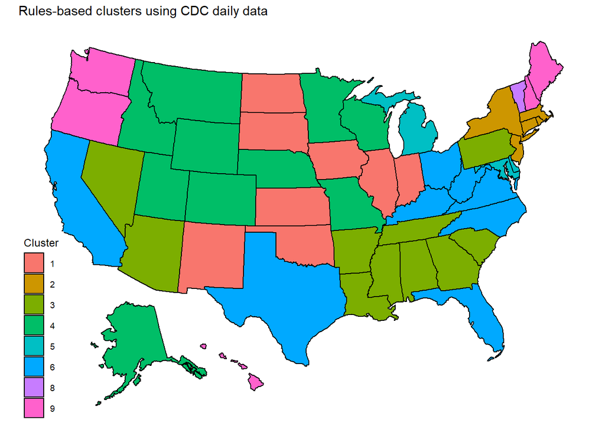

```r
# Example for rules-based clustering
clRules <- clusterStates(df=cdcPerCapita,
                         hierarchical=NA,
                         returnList=TRUE,
                         shapeFunc=customTimeBucket,
                         minShape="2020-04",
                         maxShape="2021-03",
                         hmlSegs=3,
                         eslSegs=3,
                         seed=2104221520
                         )
tibble::tibble(state=names(clRules$objCluster), cluster=factor(unname(clRules$objCluster))) %>%
    usmap::plot_usmap(regions="states", values="cluster", data=.) +
    labs(title="Rules-based clusters using CDC daily data") +
    scale_fill_discrete("Cluster")
```

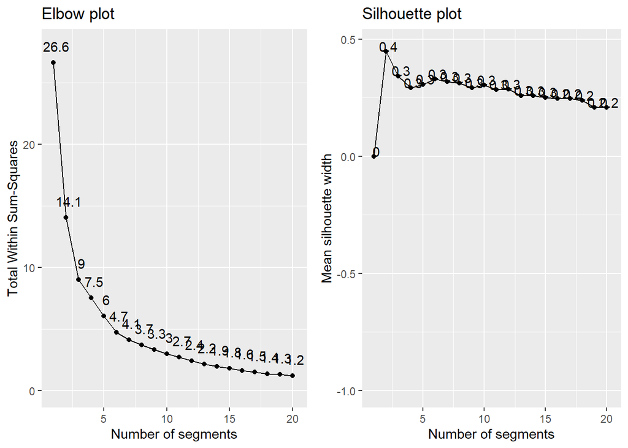

```
##
## Cluster means and counts
##                   1    2    3    4    5     6     7
## .              4.00 8.00 2.00 7.00 5.00 14.00 11.00
## totalCases     2.58 1.87 2.03 1.43 0.70  2.06  1.93
## totalDeaths    1.90 1.93 0.46 1.11 0.42  1.48  1.06
## cases_2020-04  0.02 0.07 0.01 0.04 0.02  0.02  0.01
## deaths_2020-04 0.04 0.19 0.02 0.11 0.09  0.04  0.03
## cases_2020-05  0.02 0.04 0.01 0.04 0.01  0.02  0.02
## deaths_2020-05 0.07 0.13 0.02 0.12 0.03  0.05  0.04
## cases_2020-06  0.03 0.02 0.02 0.02 0.02  0.03  0.02
## deaths_2020-06 0.03 0.05 0.02 0.06 0.02  0.04  0.03
## cases_2020-07  0.04 0.05 0.04 0.03 0.04  0.07  0.05
## deaths_2020-07 0.04 0.04 0.05 0.03 0.03  0.05  0.03
## cases_2020-08  0.04 0.04 0.03 0.03 0.07  0.06  0.04
## deaths_2020-08 0.04 0.04 0.05 0.03 0.05  0.06  0.04
## cases_2020-09  0.05 0.03 0.05 0.03 0.05  0.05  0.05
## deaths_2020-09 0.04 0.03 0.04 0.03 0.05  0.05  0.05
## cases_2020-10  0.13 0.05 0.12 0.06 0.05  0.07  0.11
## deaths_2020-10 0.09 0.03 0.08 0.03 0.06  0.06  0.07
## cases_2020-11  0.23 0.12 0.24 0.16 0.13  0.17  0.23
## deaths_2020-11 0.17 0.05 0.13 0.07 0.07  0.10  0.13
## cases_2020-12  0.19 0.21 0.22 0.21 0.20  0.21  0.21
## deaths_2020-12 0.21 0.12 0.23 0.18 0.19  0.18  0.21
## cases_2021-01  0.15 0.21 0.15 0.19 0.21  0.19  0.16
## deaths_2021-01 0.16 0.16 0.18 0.17 0.23  0.19  0.18
## cases_2021-02  0.05 0.09 0.06 0.08 0.10  0.07  0.06
## deaths_2021-02 0.08 0.10 0.11 0.10 0.12  0.12  0.11
## cases_2021-03  0.05 0.08 0.05 0.09 0.11  0.04  0.04
## deaths_2021-03 0.03 0.05 0.08 0.06 0.07  0.05  0.07
```

```r
# Example for kmeans clustering (elbow plot)
# Return 7 segments
clKMeans <- clusterStates(df=cdcPerCapita,
                          hierarchical=FALSE,
                          returnList=TRUE,
                          shapeFunc=customTimeBucket,
                          minShape="2020-04",
                          maxShape="2021-03",
                          nCenters=7,
                          iter.max=50,
                          nstart=25,
                          testCenters=1:20,
                          seed=2104221530
                          )
```

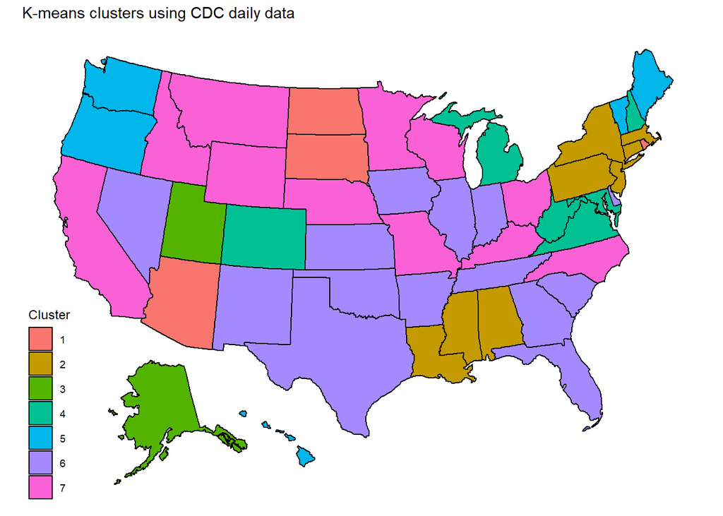

```r
tibble::tibble(state=names(clKMeans$objCluster$cluster),
               cluster=factor(unname(clKMeans$objCluster$cluster))
               ) %>%
    usmap::plot_usmap(regions="states", values="cluster", data=.) +
    labs(title="K-means clusters using CDC daily data") +
    scale_fill_discrete("Cluster")
```

```r
# Example for hierarchical clustering (clusters)
clHier <- clusterStates(cdcPerCapita,
                        hierarchical=TRUE,
                        returnList=FALSE,
                        shapeFunc=customTimeBucket,
                        minShape="2020-04",
                        maxShape="2021-01"
                        )
```

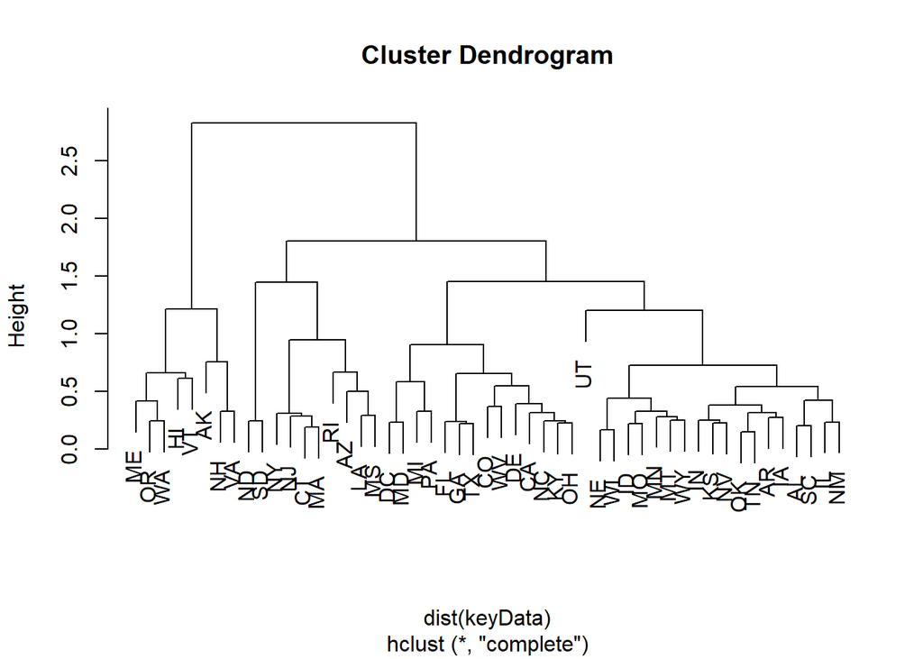

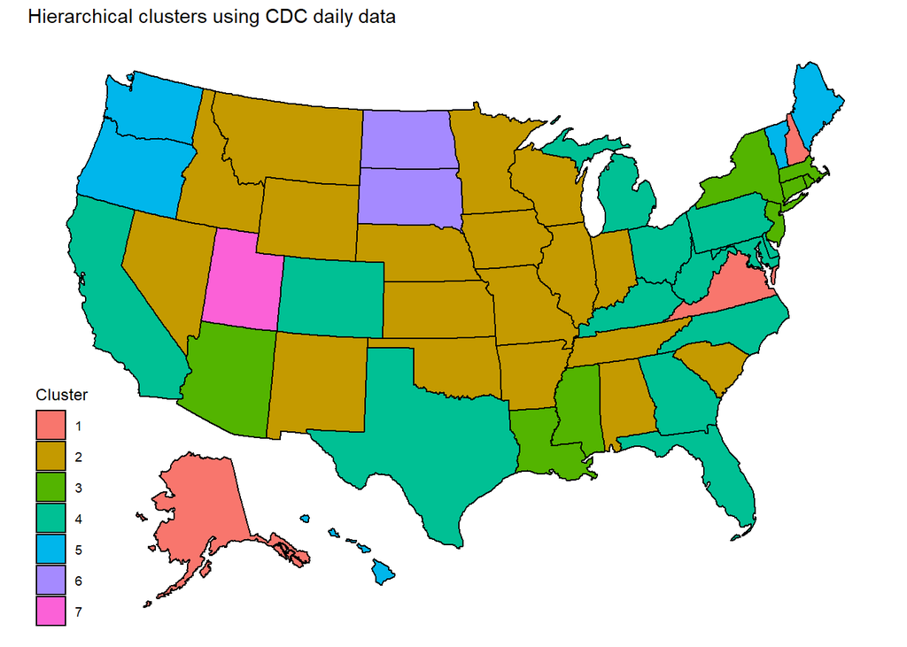

```r
tibble::tibble(state=names(cutree(clHier, k=7)),
               cluster=factor(unname(cutree(clHier, k=7)))
               ) %>%
    usmap::plot_usmap(regions="states", values="cluster", data=.) +
    labs(title="Hierarchical clusters using CDC daily data") +
    scale_fill_discrete("Cluster")
```

There are some meaningful differences in segment membership depending on method, suggestive that there may have been some convergence of outcomes across states. Generally, the heavy/hard cluster centered around NY and the light/late cluster centered in the NE/NW tend to appear in each approach. The rules-based segments look reasonably similar to those generated previously.

Next steps are to generate descriptive plots for the segments. The code for assessClusters() is copied and adapted:

```r
# # STEP 6: Create the cluster assessments
# plotData <- assessClusters(useClusters,
#                            dfState=stateData,
#                            dfBurden=dfPerCapita,
#                            thruLabel=thruLabel,
#                            plotsTogether=TRUE
#                            )


# Function to reorder and relabel factors
changeOrderLabel <- function(df,
                             fctVar="cluster",
                             grpVars=c(),
                             burdenVar="dpm",
                             wgtVar="pop",
                             exclfct="999"
                             ) {

    # FUNCTION ARGUMENTS
    # df: the data frame
    # fctVar: the factor variable
    # grpVars: the variable that the data are aurrently at (e.g., "fipsCounty" for county-level in df)
    # burdenVar: the disease burden variable for sorting
    # wgtVar: the weight variable for sorting
    # exclfct: the factor level to be excluded from analysis

    # General approach
    # 1. Data are aggregated to c(fctVar, grpVars) as x=sum(burdenVar*wgtVar) and y=mean(wgtVar)
    # 2. Data are aggregated to fctVar as z=sum(x)/sum(y)
    # 3. Factors are reordered from high to low on z, with the excluded factor added back last (if it exists)

    # Check if exclfct exists in the factor variable
    fctDummy <- exclfct %in% levels(df[, fctVar, drop=TRUE])

    # Create the summary of impact by segment
    newLevels <- df %>%
        filter(get(fctVar) != exclfct) %>%
        group_by_at(vars(all_of(c(fctVar, grpVars)))) %>%
        summarize(x=sum(get(burdenVar)*get(wgtVar)), y=mean(get(wgtVar)), .groups="drop") %>%
        group_by_at(vars(all_of(fctVar))) %>%
        summarize(z=sum(x)/sum(y), .groups="drop") %>%
        arrange(-z) %>%
        pull(fctVar) %>%
        as.character()

    # Add back the dummy factor at the end (if it exists)
    if (fctDummy) newLevels <- c(newLevels, exclfct)

    # Reassign the levels in df
    df %>%
        mutate(!!fctVar:=factor(get(fctVar), levels=newLevels, labels=newLevels))

}


# Helper function to make the overall cluster summary statistics
helperClusterSummaryPlots <- function(dfState,
                                      dfPlot,
                                      showMap,
                                      clusterPlotsTogether,
                                      weightedMean=TRUE,
                                      mapLevel="states",
                                      p3Vars=c("cases"="cpm7", "deaths"="dpm7"),
                                      p4Vars=c("cases"="cases", "deaths"="deaths"),
                                      p4Fun=sum
                                      ) {

    # FUNCTION ARGUMENTS:
    # dfState: contains the state/county-level data
    # dfPlot: contains the joined data for plotting
    # showMap: boolean for whether to create a map (if FALSE, segment membership counts are shown instead)
    # clusterPlotsTogether: boolean, whether to put all four plots on the same page
    # weightedMean: boolean, whether to create weighted mean by segment (if FALSE, median by segment is taken)
    # mapLevel: the level to be used on the map
    # p3Vars: the variables to be included in plot 3 (character vector of length 2, plotName=variableName)
    # p4Vars: the variables to be included in plot 4 (character vector of length 2, plotName=variableName)
    # p4Fun: the function to be applied in plot 4 (sum for sum of daily, max for max of cumulative)

    # Reorder the cluster levels in dfState to match dfPlot
    # Convert factor order to match dfPlot (can be reordered by argument to the calling function)
    dfState <- dfState %>%
        mutate(cluster=factor(cluster, levels=levels(dfPlot$cluster)))

    # Plot the segments on a map or show segment membership
    if (showMap) {
        if (mapLevel=="counties") {
            dfMap <- dfState %>%
                mutate(fips=stringr::str_pad(state, width=5, side="left", pad="0")) %>%
                select(fips, cluster)
        } else {
            dfMap <- dfState
        }
        # Create the map
        p1 <- usmap::plot_usmap(regions=mapLevel, data=dfMap, values="cluster") +
            scale_fill_discrete("cluster") +
            theme(legend.position="right")
    } else {
        p1 <- dfState %>%
            count(cluster) %>%
            ggplot(aes(x=fct_rev(cluster), y=n)) +
            geom_col(aes(fill=cluster)) +
            geom_text(aes(y=n/2, label=n)) +
            coord_flip() +
            labs(x="", y="# Counties", title="Membership by segment")
    }

    # Plot the population totals by segment
    # Show population totals by cluster
    p2 <- dfState %>%
        group_by(cluster) %>%
        summarize(pop=sum(pop)/1000000, .groups="drop") %>%
        ggplot(aes(x=fct_rev(cluster), y=pop)) +
        geom_col(aes(fill=cluster)) +
        geom_text(aes(y=pop/2, label=round(pop))) +
        labs(y="Population (millions)", x="Cluster", title="Population by cluster (millions)") +
        coord_flip()

    # Plot the rolling 7-day mean daily disease burden by cluster
    # Create the p3Data to be either median of all elements in cluster or weighted mean
    p3 <- dfPlot %>%
        select_at(vars(all_of(c("date", "cluster", unname(p3Vars), "pop")))) %>%
        purrr::set_names(c("date", "cluster", names(p3Vars), "pop")) %>%
        pivot_longer((-c(date, cluster, pop))) %>%
        filter(!is.na(value)) %>%
        group_by(date, cluster, name) %>%
        summarize(mdnValue=median(value), wtdValue=sum(pop*value)/sum(pop), .groups="drop") %>%
        ggplot(aes(x=date, y=if(weightedMean) wtdValue else mdnValue)) +
        geom_line(aes(group=cluster, color=cluster)) +
        facet_wrap(~name, scales="free_y") +
        labs(x="",
             y="Rolling 7-day mean, per million",
             title="Rolling 7-day mean daily disease burden, per million",
             subtitle=paste0(if(weightedMean) "Weighted mean" else "Median",
                             " per day for states assigned to cluster"
             )
        ) +
        scale_x_date(date_breaks="1 months", date_labels="%b")
```

```r
    # Plot the total cases and total deaths by cluster
    p4 <- dfPlot %>%
        select_at(vars(all_of(c("cluster", "date", unname(p4Vars))))) %>%
        purrr::set_names(c("cluster", "date", names(p4Vars))) %>%
        group_by(cluster, date) %>%
        summarize_all(.funs=sum) %>% # Get the total by cluster-date so that it can then be summed/maxed
        group_by(cluster) %>%
        summarize_at(vars(names(p4Vars)), .funs=p4Fun) %>%
        ungroup() %>%
        pivot_longer(-cluster) %>%
        ggplot(aes(x=fct_rev(cluster), y=value/1000)) +
        geom_col(aes(fill=cluster)) +
        geom_text(aes(y=value/2000, label=round(value/1000))) +
        coord_flip() +
        facet_wrap(~varMapper[name], scales="free_x") +
        labs(x="Cluster", y="Burden (000s)", title="Total burden by segment")

    # Place the plots together if plotsTogether is TRUE, otherwise just print
    if (isTRUE(clusterPlotsTogether)) {
        gridExtra::grid.arrange(p1, p2, p3, p4, nrow=2, ncol=2)
    } else {
        print(p1); print(p2); print(p3); print(p4)
    }

}


# Function to create side-by-side plots for a deaths and cases metric
# Data in df will be aggregated to be unique by byVar using aggFunc
helperBarDeathsCases <- function(df,
                                 numVars,
                                 title="",
                                 xVar="state",
                                 fillVar=NULL,
                                 aggFunc=sum,
                                 mapper=varMapper
                                 ) {

    # FUNCTION ARGUMENTS:
    # df: the data frame containing the data
    # numVars: the relevant numeric variables for plotting
    # title: plot title, default is nothing
    # xVar: the x-axis variable for plotting
    # fillVar: the variable that will color the bars in the final plot (NULL means use "lightblue" for all)
    # aggFunc: the aggregate function (will be applied to create data unique by byVar)
    # mapper: mapping file to convert x/y variables to descriptive axes (named vector "variable"="label")

    # OVERALL FUNCTION PROCESS:
    # 1.  Variables in numVar are aggregated by aggFunc to be unique by c(xVar, fillVar)
    # 2.  Data are pivoted longer
    # 3.  Bar charts are created, with coloring by fillVar if provided

    # Create the byVar for summing
    byVar <- xVar
    if (!is.null(fillVar)) { byVar <- c(byVar, fillVar) }

    # Process the data and create the plot
    p1 <- df %>%
        select_at(vars(all_of(c(byVar, numVars)))) %>%
        group_by_at(vars(all_of(byVar))) %>%
        summarize_all(aggFunc) %>%
        pivot_longer(-all_of(byVar)) %>%
        ggplot(aes(x=fct_reorder(get(xVar), value, .fun=min), y=value)) +
        coord_flip() +
        facet_wrap(~mapper[name], scales="free_x") +
        labs(x="", y="", title=title) +
        if (is.null(fillVar)) geom_col(fill="lightblue") else geom_col(aes_string(fill=fillVar))

    # Print the plot
    print(p1)

}


# Helper function to make total and per capita by state (calls its own helper function)
helperCallTotalPerCapita <- function(dfPlot,
                                     thruLabel,
                                     isCDC=FALSE
                                     ) {

    # FUNCTION ARGUMENTS:
    # dfPlot: the plotting data frame
    # thruLabel: the date that data are through
    # isCDC: boolean, are the data from CDC daily rather than CTP?

    # Plot total cases and total deaths by state, colored by cluster
    helperBarDeathsCases(dfPlot,
                         numVars=if(isTRUE(isCDC)) c("tot_cases", "tot_deaths") else c("cases", "deaths"),
                         title=paste0("Coronavirus impact by state through ", thruLabel),
                         xVar=c("state"),
                         fillVar=c("cluster"),
                         aggFunc=if(isTRUE(isCDC)) max else sum
                         )

    # Plot cases per million and deaths per million by state, colored by cluster
    helperBarDeathsCases(dfPlot,
                         numVars=if(isTRUE(isCDC)) c("tcpm", "tdpm") else c("cpm", "dpm"),
                         title=paste0("Coronavirus impact by state through ", thruLabel),
                         xVar=c("state"),
                         fillVar=c("cluster"),
                         aggFunc=if(isTRUE(isCDC)) max else sum
                         )

}


# Helper function to assess 30-day change vs. total
helperRecentvsTotal <- function(df,
                                xVar,
                                yVar,
                                title,
                                recencyDays=30,
                                ablineSlope=0.5,
                                mapper=varMapper,
                                labelPlot=TRUE,
                                printPlot=TRUE,
                                isCDC=FALSE
                                ) {

    # FUNCTION ARGUMENTS:
    # df: the tibble containing data by state by day
    # xVar: the x-variable
    # yVar: the y-variable
    # title: the plot title
    # recencyDays: number of days to consider as recent
    # ablineSlope: dashed line will be drawn with this slope and intercept 0
    # mapper: mapping file to convert x/y variables to descriptive axes (named vector "variable"="label")
    # labelPlot: boolean, whether to show the labels for each point
    # printPlot: boolean, whether to display the plot (if FALSE, plot object is returned)
    # isCDC: boolean, are the data from CDC daily rather than CTP?

    # Get the most date cutoff
    dateCutoff <- df %>% pull(date) %>% max() - recencyDays + 1
    cat("\nRecency is defined as", format(dateCutoff, "%Y-%m-%d"), "through current\n")

    # For CDC data, set tcpm and tdpm to 0 except for the last date
    if(isTRUE(isCDC)) {
        df <- df %>%
            group_by(state) %>%
            mutate(tcpm=ifelse(date==max(date), tcpm, 0), tdpm=ifelse(date==max(date), tdpm, 0)) %>%
            ungroup()
    }
```

```r
    # Create the plot
    p1 <- df %>%
        mutate(newCases=ifelse(date >= dateCutoff, if(isTRUE(isCDC)) new_cases else cases, 0),
               newDeaths=ifelse(date >= dateCutoff, if (isTRUE(isCDC)) new_deaths else deaths, 0),
               newcpm=ifelse(date >= dateCutoff, cpm, 0),
               newdpm=ifelse(date >= dateCutoff, dpm, 0)
        ) %>%
        group_by(state, cluster) %>%
        summarize_if(is.numeric, .funs=sum) %>%
        ungroup() %>%
        ggplot(aes_string(x=xVar, y=yVar)) +
        labs(x=mapper[xVar],
             y=mapper[yVar],
             title=title,
             subtitle=paste0("Dashed line represents ",
                             round(100*ablineSlope),
                             "% of total is new in last ",
                             recencyDays,
                             " days"
             )
        ) +
        geom_abline(lty=2, slope=ablineSlope) +
        lims(x=c(0, NA), y=c(0, NA)) +
        theme(legend.position = "bottom")

    # Add the appropriate geom (scatterplot if labelPlot is FALSE)
    if (labelPlot) p1 <- p1 + geom_text(aes(color=cluster, label=state))
    else p1 <- p1 + geom_point(aes(color=cluster), alpha=0.5)

    if (isTRUE(printPlot)) {
        print(p1)
    } else {
        p1
    }

}


# Helper function to make recent vs. total plots
helperCallRecentvsTotal <- function(dfPlot,
                                    thruLabel,
                                    labelPoints,
                                    recentTotalTogether,
                                    isCDC=FALSE
                                    ) {

    # FUNCTION ARGUMENTS:
    # dfPlot: the plotting data frame
    # thruLabel: the date that data are through
    # labelPoints: boolean, whether to label the individual points
    # recentTotalTogether: boolean, whether to put these plots together on one page
    # isCDC: boolean, are the data from CDC daily rather than CTP?

    # Plot last-30 vs total for cases per million by state, colored by cluster
    p7 <- helperRecentvsTotal(dfPlot,
                              xVar=if(isTRUE(isCDC)) "tcpm" else "cpm",
                              yVar="newcpm",
                              title=paste0("Coronavirus burden through ", thruLabel),
                              labelPlot=labelPoints,
                              printPlot=FALSE,
                              isCDC=isCDC
    )

    # Plot last-30 vs total for deaths per million by state, colored by cluster
    p8 <- helperRecentvsTotal(dfPlot,
                              xVar=if(isTRUE(isCDC)) "tdpm" else "dpm",
                              yVar="newdpm",
                              title=paste0("Coronavirus burden through ", thruLabel),
                              labelPlot=labelPoints,
                              printPlot=FALSE,
                              isCDC=isCDC
    )

    # Print the plots either as a single page or separately
    if (isTRUE(recentTotalTogether)) {
        gridExtra::grid.arrange(p7, p8, nrow=1)
    } else {
        print(p7); print(p8)
    }

}


# Function to plot cluster vs. individual elements on a key metric
helperTotalvsElements <- function(df,
                                  keyVar,
                                  title,
                                  aggAndTotal=TRUE,
                                  pctRibbon=0.8,
                                  aggFunc=if(aggAndTotal) median else mean,
                                  mapper=varMapper,
                                  facetScales="free_y",
                                  printPlot=TRUE
                                  ) {

    # FUNCTION ARGUMENTS:
    # df: the data frame containing n-day rolling averages
    # keyVar: the variable to be plotted
    # title: the plot title
    # aggAndTotal: boolean, whether to plot every individual observation along with the cluster aggregate
    # pctRibbon: if aggAndTotal is FALSE, a ribbon covering this percentage of the data will be plotted
    # aggFunc: how to aggregate the elements to the segment
    #          CAUTION that this is an aggregate of averages, rather than a population-weighted aggregate
    # mapper: the variable mapping file to get the appropriate label for keyVar
    # facetScales: the scaling for the facets - "free_y" to let them all float, "fixed" to have them the same
    # printPlot: boolean, if TRUE print the plot (otherwise return the plot object)

    # Create an appropriate subtitle
    subtitle <- if(facetScales=="free_y") {
        "Caution that each facet has its own y axis with different scales"
    } else if (facetScales=="fixed") {
        "All facets are on the same scale"
    } else {
        "Update subtitle code in function helperTotalvsElements"
    }

    # Create an appropriate caption
    xCap <- "1. Cluster aggregate is mean over all observations (NOT population-weighted)"
    xCap <- paste0(xCap, "\n2. Ribbons reflect range covering ", round(pctRibbon*100), "% of observations")
    caption <- if(aggAndTotal) {
        "Cluster aggregate is median, weighting each observation equally\n(NOT population-weighted)"
    } else {
        xCap
    }

    # Create the plots for segment-level data
    p1 <- df %>%
        rbind(mutate(., state="cluster")) %>%
        group_by(state, cluster, date) %>%
        summarize_at(vars(all_of(keyVar)), .funs=aggFunc) %>%
        ungroup() %>%
        filter(!is.na(get(keyVar))) %>%
        ggplot(aes_string(x="date")) +
        geom_line(data=~filter(., state == "cluster"),
                  aes(y=get(keyVar), group=state, color=cluster),
                  lwd=1.5
        ) +
        facet_wrap(~cluster, scales=facetScales) +
        labs(x="",
             y=mapper[keyVar],
             title=title,
             subtitle=subtitle,
             caption=caption
        ) +
        ylim(c(0, NA)) +
        theme(legend.position="bottom")

    # Add an appropriate individual metric (either every observation or quantiles)
    if (aggAndTotal) {
        p1 <- p1 +
            geom_line(data=~filter(., state != "cluster"),
                      aes(y=get(keyVar), group=state),
                      alpha=0.25
            )
    } else {
        dfRibbon <- df %>%
            filter(!is.na(get(keyVar))) %>%
            group_by(cluster, date) %>%
            summarize(ylow=quantile(get(keyVar), 0.5-0.5*pctRibbon),
                      yhigh=quantile(get(keyVar), 0.5+0.5*pctRibbon),
                      .groups="drop"
            )
        p1 <- p1 +
            geom_ribbon(data=dfRibbon,
                        aes(ymin=ylow, ymax=yhigh),
                        alpha=0.25
            )
    }
```

```r
    # Print plot if requested, otherwise return it
    if (isTRUE(printPlot)) {
        print(p1)
    } else {
        p1
    }

}


# Helper function to create total vs. elements plots
helperCallTotalvsElements <- function(dfPlot,
                                      aggAndTotal,
                                      clusterAggTogether,
                                      ...
                                      ) {

    # FUNCTION ARGUMENTS:
    # dfPlot: the plotting data frame
    # aggAndTotal: boolean, should each individual line be plotted (if FALSE an 80% CI is plotted instead)
    # clusterAggTogether: boolean, whether to print the plots all on a single page
    # ...: any other arguments to pass to helperTotalvsElements (especially pctRibbon or aggFunc)

    # Plot the cases per million on a free y-scale and a fixed y-scale
    p9 <- helperTotalvsElements(dfPlot,
                                keyVar="cpm7",
                                aggAndTotal=aggAndTotal,
                                title="Cases per million, 7-day rolling mean",
                                printPlot=FALSE,
                                ...
    )
    p10 <- helperTotalvsElements(dfPlot,
                                 keyVar="cpm7",
                                 aggAndTotal=aggAndTotal,
                                 title="Cases per million, 7-day rolling mean",
                                 facetScales="fixed",
                                 printPlot=FALSE,
                                 ...
    )

    # Plot the deaths per million on a free y-scale and a fixed y-scale
    p11 <- helperTotalvsElements(dfPlot,
                                 keyVar="dpm7",
                                 aggAndTotal=aggAndTotal,
                                 title="Deaths per million, 7-day rolling mean",
                                 printPlot=FALSE,
                                 ...
    )
    p12 <- helperTotalvsElements(dfPlot,
                                 keyVar="dpm7",
                                 aggAndTotal=aggAndTotal,
                                 title="Deaths per million, 7-day rolling mean",
                                 facetScales="fixed",
                                 printPlot=FALSE,
                                 ...
    )

    if (isTRUE(clusterAggTogether)) {
        gridExtra::grid.arrange(p9, p11, nrow=1)
        gridExtra::grid.arrange(p10, p12, nrow=1)
    } else {
        print(p9); print(p10); print(p11); print(p12)
    }

}


# assessClusters() function
assessClusters <- function(clusters,
                           dfState=stateData,
                           dfBurden=cvFilteredPerCapita,
                           thruLabel="Aug 20, 2020",
                           isCounty=FALSE,
                           plotsTogether=FALSE,
                           clusterPlotsTogether=plotsTogether,
                           recentTotalTogether=plotsTogether,
                           clusterAggTogether=plotsTogether,
                           makeSummaryPlots=TRUE,
                           makeTotalvsPerCapitaPlots=!isCounty,
                           makeRecentvsTotalPlots=TRUE,
                           makeTotalvsElementPlots=TRUE,
                           showMap=!isCounty,
                           orderCluster=FALSE,
                           isCDC=FALSE,
                           p3Vars=c("cases"="cpm7", "deaths"="dpm7"),
                           p4Vars=c("cases"="cases", "deaths"="deaths"),
                           p4Fun=sum
                           ) {

    # FUNCTION ARGUMENTS:
    # clusters: the named vector containing the clusters by state
    # dfState: the file containing the states and populations
    # dfBurden: the data containing the relevant per capita burden statistics by state-date
    # thruLabel: label for plots for 'data through'
    # isCounty: boolean, is this a plot of county-level data that have been named 'state'?
    #           FALSE means that it is normal state-level data
    # plotsTogether: boolean, should plots be consolidated on fewer pages?
    # clusterPlotsTogether: boolean, should plots p1-p4 be consolidated?
    # recentTotalTogether: boolean, should recent total plots p7-p8 be consolidated?
    # clusterAggTogether: boolean, should aggregate plots p9/p11 and p10/p12 be consolidated?
    # makeSummaryPlots: boolean, should the summary plots be made?
    # makeTotalvsPerCapitaPlots: boolean, should the total and per capita plots be produced?
    # makeRecentvsTotalPlots: boolean, should the recent vs. total plots be created?
    # makeTotalvsElementPlots: boolean, should the total vs. element plots be created?
    # showMap: boolean, whether to create a map colored by cluster (will show segment counts otherwise)
    # orderCluster: if FALSE, ignore; if TRUE, order by "dpm"; if anything else, order by orderCluster
    # isCDC: boolean, are the data from CDC daily rather than CTP?
    # p3Vars: the variables to be included in plot 3 (character vector of length 2, plotName=variableName)
    # p4Vars: the variables to be included in plot 4 (character vector of length 2, plotName=variableName)
    # p4Fun: the function to be applied in plot 4 (sum for sum of daily, max for max of cumulative)
    # ...: any additional arguments passed from a calling function
    #      most common would be orderCluster=TRUE, a request for the clusters to be ordered by disease burden

    # Attach the clusters to the state population data
    dfState <- as.data.frame(clusters) %>%
        set_names("cluster") %>%
        rownames_to_column("state") %>%
        inner_join(dfState, by="state") %>%
        mutate(cluster=factor(cluster))

    # Plot the rolling 7-day mean dialy disease burden by cluster
    dfPlot <- dfState %>%
        inner_join(dfBurden, by="state") %>%
        tibble::as_tibble()

    # Reorder the clusters if requested
    if (!isFALSE(orderCluster)) {
        if (isTRUE(orderCluster)) burdenParam <- "dpm" else burdenParam <- orderCluster
        dfPlot <- changeOrderLabel(dfPlot, grpVars="state", burdenVar=burdenParam)
    }
```

```r
    # Call the helper function to make the overall summary statistics
    if (makeSummaryPlots) {
        helperClusterSummaryPlots(dfState=dfState,
                                  dfPlot=dfPlot,
                                  showMap=showMap,
                                  clusterPlotsTogether=clusterPlotsTogether,
                                  mapLevel=if(isCounty) "counties" else "states",
                                  p3Vars=p3Vars,
                                  p4Vars=p4Vars,
                                  p4Fun=p4Fun
                                  )
    }

    # These are primarily useful for state-level data and default to FALSE when isCounty is TRUE
    if (makeTotalvsPerCapitaPlots) {
        helperCallTotalPerCapita(dfPlot=dfPlot, thruLabel=thruLabel, isCDC=isCDC)
    }

    # Call the helper function to make recent vs. total plots
    if (makeRecentvsTotalPlots) {
        helperCallRecentvsTotal(dfPlot=dfPlot,
                                thruLabel=thruLabel,
                                labelPoints=!isCounty,
                                recentTotalTogether=recentTotalTogether,
                                isCDC=isCDC
                                )
    }

    # Call the total vs. elements helper function
    if (makeTotalvsElementPlots) {
        helperCallTotalvsElements(dfPlot=dfPlot,
                                  aggAndTotal=!isCounty,
                                  clusterAggTogether=clusterPlotsTogether
        )
    }

    # Return the plotting data frame
    dfPlot

}
```